# Blazars/non-blazars samples definition: 5BzCat

This note is to define the samples of blazars and non-blazar objects for future data analysis. Eventually, we will have a list of coordinates (RA,Dec), `ID` and *class* for each sample.

We are going to use the 5BzCat catalog of blazars (~3000 objects) and a list of AGNs from Paolo (~13k objects).

```python
import matplotlib
from matplotlib import pyplot as plt
%matplotlib inline

import seaborn as sns
print(sns.__version__)

import pandas as pd
print(pd.__version__)
```

```
0.9.0
0.23.4
```

```python
%ls
```

```
4carlosAll.csv              AGNSample_Label_RA_DEC.csv
4carlosAll.csv.BKP          AGN_AllColumns.csv
4carlosSeyf.txt             All_AGNs.ipynb
4carlosall.txt              BzCat.ipynb
5BZCAT.csv*                 PastedGraphic-1.pdf
5BZCAT.csv.BKP*             VOU_Blazars/
5bzcat_label_ra_dec.csv     tmp/
AGNSample_AllColumns.csv    work/
```

## 5BzCat: Blazars sample

```python
bzcat = pd.read_csv('5BZCAT.csv')
bzcat.sample(10)
```

|  | id | Source name | RA (J2000.0) | Dec (J2000.0) | Redshift | Rmag | Source classification | Flux density 1.4/0.843GHz(mJy) | Flux density 143GHz(mJy) | X-ray flux 0.1-2.4 keV(1.e-12 cgs) | Fermi flux 1-100 GeV(ph/cm2/s) |
| --- | --- | --- | --- | --- | --- | --- | --- | --- | --- | --- | --- |
| 538 | 539 | 5BZQJ0332-4455 | 53.18379 | -44.93250 | 2.679 | 17.1 | QSO RLoud flat radio sp. | 111.0 | 0 | 0.20 | 7.000000e-10 |
| 2450 | 2451 | 5BZQJ1506+3730 | 226.53971 | 37.51419 | 0.672 | 21.2 | QSO RLoud flat radio sp. | 938.0 | 566 | 0.37 | 7.000000e-10 |
| 3035 | 3036 | 5BZQJ1959-4246 | 299.80579 | -42.76883 | 2.178 | 19.7 | QSO RLoud flat radio sp. | 163.0 | 318 | 0.29 | 2.500000e-09 |
| 3050 | 3051 | 5BZQJ2007+6607 | 301.86988 | 66.12292 | 1.325 | 20.3 | QSO RLoud flat radio sp. | 509.0 | 188 | 0.00 | 0.000000e+00 |
| 3307 | 3308 | 5BZQJ2228-0753 | 337.21921 | -7.89628 | 0.638 | 18.0 | QSO RLoud flat radio sp. | 173.0 | 0 | 0.48 | 0.000000e+00 |
| 3163 | 3164 | 5BZQJ2123+0535 | 320.93550 | 5.58947 | 1.941 | 17.4 | QSO RLoud flat radio sp. | 794.0 | 460 | 0.35 | 0.000000e+00 |
| 1652 | 1653 | 5BZBJ1112+1751 | 168.10250 | 17.85606 | 0.421 | 18.4 | BL Lac | 14.0 | 0 | 1.50 | 0.000000e+00 |
| 611 | 612 | 5BZQJ0410-7750 | 62.67629 | -77.84536 | 2.449 | 18.6 | QSO RLoud flat radio sp. | 440.0 | 0 | 0.00 | 0.000000e+00 |
| 3378 | 3379 | 5BZBJ2254-2725 | 343.72175 | -27.41914 | 0.333 | 17.8 | BL Lac | 53.0 | 0 | 0.00 | 0.000000e+00 |
| 1043 | 1044 | 5BZBJ0806+1330 | 121.56375 | 13.50556 | 0.504 | 19.7 | BL Lac | 14.0 | 0 | 0.00 | 0.000000e+00 |

### Define the columns of interest

```python
col = dict(ra = 'RA (J2000.0)',
           dec = 'Dec (J2000.0)',
           idn = 'id',
           name = 'Source name',
           flux_radio = 'Flux density 1.4/0.843GHz(mJy)',
           klass = 'Source classification',
           flux_opt = 'Rmag',
           flux_xray = 'X-ray flux 0.1-2.4 keV(1.e-12 cgs)',
           redshift = 'Redshift',
          )
```

```python
# Keep only the columns of interest

bzcat = bzcat[list(col.values())]
bzcat
```

|  | RA (J2000.0) | Dec (J2000.0) | id | Source name | Flux density 1.4/0.843GHz(mJy) | Source classification | Rmag | X-ray flux 0.1-2.4 keV(1.e-12 cgs) | Redshift |
| --- | --- | --- | --- | --- | --- | --- | --- | --- | --- |
| 0 | 0.08496 | -32.35028 | 1 | 5BZQJ0000-3221 | 521.0 | QSO RLoud flat radio sp. | 18.2 | 0.05 | 1.275 |
| 1 | 0.27208 | -15.85194 | 2 | 5BZQJ0001-1551 | 348.0 | QSO RLoud flat radio sp. | 18.1 | 0.00 | 2.044 |
| 2 | 0.28592 | 19.24283 | 3 | 5BZQJ0001+1914 | 265.0 | QSO RLoud flat radio sp. | 21.6 | 0.00 | 3.1 |
| 3 | 0.32504 | -7.77408 | 4 | 5BZBJ0001-0746 | 208.0 | BL Lac | 17.9 | 0.35 | 0 |
| 4 | 0.33954 | -0.19442 | 5 | 5BZBJ0001-0011 | 111.0 | BL Lac | 19.6 | 0.00 | 0.462 ? |
| 5 | 0.48858 | -10.52147 | 6 | 5BZGJ0001-1031 | 41.0 | BL Lac-galaxy dominated | 17.8 | 0.00 | 0.252 |
| 6 | 0.73817 | -0.41308 | 7 | 5BZBJ0002-0024 | 178.0 | BL Lac | 19.7 | 0.00 | 0.523 |
| 7 | 0.83058 | 21.49572 | 8 | 5BZQJ0003+2129 | 83.0 | QSO RLoud flat radio sp. | 20.1 | 0.00 | 0.45 |
| 8 | 1.02033 | -11.81611 | 9 | 5BZBJ0004-1148 | 459.0 | BL Lac | 18.8 | 0.00 | 0 |
| 9 | 1.06738 | 46.25506 | 10 | 5BZQJ0004+4615 | 120.0 | QSO RLoud flat radio sp. | 20.4 | 0.00 | 1.81 |
| 10 | 1.14850 | -47.60542 | 11 | 5BZQJ0004-4736 | 909.0 | QSO RLoud flat radio sp. | 15.9 | 0.85 | 0.884 |
| 11 | 1.14896 | 20.32850 | 12 | 5BZQJ0004+2019 | 55.0 | QSO RLoud flat radio sp. | 21.6 | 0.00 | 0.677 |
| 12 | 1.32471 | -16.80131 | 13 | 5BZQJ0005-1648 | 263.0 | QSO RLoud flat radio sp. | 18.4 | 0.44 | 0.78 |
| 13 | 1.33421 | 5.40303 | 14 | 5BZQJ0005+0524 | 127.0 | QSO RLoud flat radio sp. | 16.2 | 0.26 | 1.9 |
| 14 | 1.48825 | 38.33756 | 15 | 5BZQJ0005+3820 | 572.0 | QSO RLoud flat radio sp. | 17.6 | 0.75 | 0.229 |
| 15 | 1.55788 | -6.39311 | 16 | 5BZBJ0006-0623 | 2051.0 | BL Lac | 17.9 | 0.82 | 0.347 |
| 16 | 1.58221 | -42.75517 | 17 | 5BZQJ0006-4245 | 246.0 | QSO RLoud flat radio sp. | 18.5 | 0.00 | 1.77 ? |
| 17 | 1.58454 | 10.86436 | 18 | 5BZGJ0006+1051 | 12.0 | BL Lac-galaxy dominated | 15.6 | 1.72 | 0.168 |
| 18 | 1.70329 | 24.37681 | 19 | 5BZQJ0006+2422 | 184.0 | QSO RLoud flat radio sp. | 18.8 | 0.00 | 1.684 |
| 19 | 1.83575 | -61.21842 | 20 | 5BZQJ0007-6113 | 87.0 | QSO RLoud flat radio sp. | 19.3 | 0.00 | 0.857 |
| 20 | 1.99988 | 47.20214 | 21 | 5BZBJ0007+4712 | 60.0 | BL Lac | 18.2 | 0.53 | 0.28 ? |
| 21 | 2.00154 | -23.65497 | 22 | 5BZQJ0008-2339 | 375.0 | QSO RLoud flat radio sp. | 15.8 | 0.30 | 1.412 |
| 22 | 2.14742 | -23.65772 | 23 | 5BZBJ0008-2339 | 36.0 | BL Lac | 16.8 | 2.42 | 0.147 |
| 23 | 2.15642 | -46.32800 | 24 | 5BZQJ0008-4619 | 109.0 | QSO RLoud flat radio sp. | 16.6 | 0.00 | 1.85 |
| 24 | 2.26633 | 6.47261 | 25 | 5BZBJ0009+0628 | 247.0 | BL Lac | 18.9 | 0.55 | 0 |
| 25 | 2.32104 | 6.43186 | 26 | 5BZQJ0009+0625 | 180.0 | QSO RLoud flat radio sp. | 19.0 | 0.08 | 2.694 |
| 26 | 2.34488 | 50.50794 | 27 | 5BZBJ0009+5030 | 12.0 | BL Lac | 19.4 | 0.24 | 0 |
| 27 | 2.61979 | 20.79725 | 28 | 5BZQJ0010+2047 | 159.0 | QSO RLoud flat radio sp. | 19.3 | 0.51 | 0.6 |
| 28 | 2.62917 | 10.97489 | 29 | 5BZQJ0010+1058 | 98.0 | QSO RLoud flat radio sp. | 15.8 | 6.14 | 0.089 |
| 29 | 2.64163 | 17.40528 | 30 | 5BZQJ0010+1724 | 918.0 | QSO RLoud flat radio sp. | 16.7 | 0.65 | 1.601 |
| ... | ... | ... | ... | ... | ... | ... | ... | ... | ... |
| 3531 | 358.22071 | -28.43111 | 3532 | 5BZQJ2352-2825 | 79.0 | QSO RLoud flat radio sp. | 19.1 | 0.00 | 1.662 |
| 3532 | 358.29775 | -27.72378 | 3533 | 5BZQJ2353-2743 | 169.0 | QSO RLoud flat radio sp. | 17.9 | 0.34 | 0.889 |
| 3533 | 358.33800 | -14.98253 | 3534 | 5BZBJ2353-1458 | 14.0 | BL Lac Candidate | 19.5 | 1.70 | 0 |
| 3534 | 358.42625 | 55.31131 | 3535 | 5BZQJ2353+5518 | 221.0 | QSO RLoud flat radio sp. | 18.3 | 0.00 | 1.927 |
| 3535 | 358.44775 | -30.63014 | 3536 | 5BZBJ2353-3037 | 397.0 | BL Lac | 16.6 | 0.22 | 0.737 |
| 3536 | 358.52313 | -9.96361 | 3537 | 5BZQJ2354-0957 | 199.0 | QSO RLoud flat radio sp. | 21.2 | 0.11 | 0.989 |
| 3537 | 358.53825 | -0.33000 | 3538 | 5BZQJ2354-0019 | 350.0 | QSO RLoud flat radio sp. | 18.0 | 0.00 | 0.462 |
| 3538 | 358.54633 | -41.10531 | 3539 | 5BZUJ2354-4106 | 620.0 | Blazar Uncertain type | 23.2 | 0.00 | 0.632 |
| 3539 | 358.59033 | 45.88450 | 3540 | 5BZQJ2354+4553 | 1872.0 | QSO RLoud flat radio sp. | 19.1 | 0.26 | 1.992 |
| 3540 | 358.62583 | -15.21978 | 3541 | 5BZQJ2354-1513 | 865.0 | QSO RLoud flat radio sp. | 18.2 | 0.47 | 2.675 |
| 3541 | 358.71529 | -4.08431 | 3542 | 5BZUJ2354-0405 | 374.0 | Blazar Uncertain type | 18.1 | 0.28 | 0.72 ? |
| 3542 | 358.85642 | -33.96592 | 3543 | 5BZQJ2355-3357 | 330.0 | QSO RLoud flat radio sp. | 16.2 | 1.14 | 0.702 |
| 3543 | 359.00283 | -68.33431 | 3544 | 5BZQJ2356-6820 | 1126.0 | QSO RLoud flat radio sp. | 15.9 | 0.40 | 1.716 |
| 3544 | 359.01671 | -0.39828 | 3545 | 5BZBJ2356-0023 | 5.0 | BL Lac | 18.5 | 0.29 | 0.283 |
| 3545 | 359.05283 | 40.61347 | 3546 | 5BZGJ2356+4036 | 25.0 | BL Lac-galaxy dominated | 14.8 | 0.00 | 0.131 |
| 3546 | 359.09542 | 81.88117 | 3547 | 5BZQJ2356+8152 | 521.0 | QSO RLoud flat radio sp. | 18.0 | 0.15 | 1.344 ? |
| 3547 | 359.27783 | 4.81575 | 3548 | 5BZQJ2357+0448 | 129.0 | QSO RLoud flat radio sp. | 20.8 | 0.00 | 1.248 |
| 3548 | 359.34938 | -24.85089 | 3549 | 5BZQJ2357-2451 | 170.0 | QSO RLoud flat radio sp. | 19.3 | 0.00 | 1.614 |
| 3549 | 359.35475 | -1.87097 | 3550 | 5BZBJ2357-0152 | 233.0 | BL Lac | 19.4 | 0.00 | 0.812 |
| 3550 | 359.37367 | -17.30147 | 3551 | 5BZBJ2357-1718 | 44.0 | BL Lac | 16.9 | 13.50 | 0 |
| 3551 | 359.38000 | -11.42756 | 3552 | 5BZQJ2357-1125 | 1814.0 | QSO RLoud flat radio sp. | 18.6 | 0.36 | 0.96 |
| 3552 | 359.47196 | -53.18714 | 3553 | 5BZQJ2357-5311 | 1411.0 | QSO RLoud flat radio sp. | 15.6 | 1.55 | 1.006 |
| 3553 | 359.50896 | -45.92181 | 3554 | 5BZQJ2358-4555 | 209.0 | QSO RLoud flat radio sp. | 18.5 | 0.00 | 0.444 |
| 3554 | 359.54533 | -10.33572 | 3555 | 5BZQJ2358-1020 | 768.0 | QSO RLoud flat radio sp. | 18.7 | 0.00 | 1.638 |
| 3555 | 359.62021 | 4.50689 | 3556 | 5BZQJ2358+0430 | 246.0 | QSO RLoud flat radio sp. | 19.1 | 0.00 | 2.298 |
| 3556 | 359.69204 | 19.92231 | 3557 | 5BZQJ2358+1955 | 673.0 | QSO RLoud flat radio sp. | 17.8 | 0.31 | 1.066 |
| 3557 | 359.74942 | 39.37453 | 3558 | 5BZQJ2358+3922 | 421.0 | QSO RLoud flat radio sp. | 19.2 | 0.40 | 1.201 |
| 3558 | 359.78296 | -30.62817 | 3559 | 5BZBJ2359-3037 | 62.0 | BL Lac | 15.8 | 40.20 | 0.165 |
| 3559 | 359.88825 | 38.84508 | 3560 | 5BZQJ2359+3850 | 524.0 | QSO RLoud flat radio sp. | 19.1 | 0.51 | 2.711 |
| 3560 | 359.89788 | -31.56217 | 3561 | 5BZQJ2359-3133 | 347.0 | QSO RLoud flat radio sp. | 19.9 | 0.27 | 0.99 |

3561 rows × 9 columns

```python
# Clean the Redshift column from '?'

bzcat[col['redshift']] = bzcat[col['redshift']].str.replace('\s*\?','')
```

```python
# And let's order our catalog by their Radio flux

bzcat = bzcat.sort_values(col['flux_radio'], ascending=False).reset_index(drop=True)
bzcat
```

|  | RA (J2000.0) | Dec (J2000.0) | id | Source name | Flux density 1.4/0.843GHz(mJy) | Source classification | Rmag | X-ray flux 0.1-2.4 keV(1.e-12 cgs) | Redshift |
| --- | --- | --- | --- | --- | --- | --- | --- | --- | --- |
| 0 | 187.27792 | 2.05239 | 1923 | 5BZQJ1229+0203 | 54992.0 | QSO RLoud flat radio sp. | 12.9 | 63.10 | 0.158 |
| 1 | 49.95067 | 41.51169 | 508 | 5BZUJ0319+4130 | 22830.0 | Blazar Uncertain type | 12.3 | 0.00 | 0.018 |
| 2 | 274.89583 | -63.76339 | 2910 | 5BZUJ1819-6345 | 19532.0 | Blazar Uncertain type | 13.4 | 1.24 | 0.063 |
| 3 | 80.74158 | -36.45856 | 759 | 5BZUJ0522-3627 | 15620.0 | Blazar Uncertain type | 14.6 | 10.40 | 0.056 |
| 4 | 277.38242 | 48.74617 | 2924 | 5BZUJ1829+4844 | 13753.0 | Blazar Uncertain type | 16.7 | 2.20 | 0.695 |
| 5 | 291.21275 | -29.24169 | 2991 | 5BZQJ1924-2914 | 13387.0 | QSO RLoud flat radio sp. | 17.3 | 2.42 | 0.353 |
| 6 | 343.49063 | 16.14822 | 3374 | 5BZQJ2253+1608 | 12657.0 | QSO RLoud flat radio sp. | 13.2 | 7.80 | 0.859 |
| 7 | 278.41638 | -21.06103 | 2930 | 5BZQJ1833-2103 | 10896.0 | QSO RLoud flat radio sp. | 21.0 | 0.69 | 2.507 |
| 8 | 194.04654 | -5.78931 | 2014 | 5BZQJ1256-0547 | 9711.0 | QSO RLoud flat radio sp. | 15.0 | 20.90 | 0.536 |
| 9 | 128.72904 | 55.57278 | 1137 | 5BZGJ0834+5534 | 8283.0 | BL Lac-galaxy dominated | 17.2 | 1.21 | 0.242 |
| 10 | 224.78158 | 71.67219 | 2433 | 5BZUJ1459+7140 | 7468.0 | Blazar Uncertain type | 17.2 | 0.77 | 0.91 |
| 11 | 336.44692 | -4.95039 | 3304 | 5BZQJ2225-0457 | 7412.0 | QSO RLoud flat radio sp. | 17.6 | 0.89 | 1.404 |
| 12 | 338.15171 | 11.73081 | 3316 | 5BZQJ2232+1143 | 7202.0 | QSO RLoud flat radio sp. | 16.7 | 1.26 | 1.037 |
| 13 | 250.74504 | 39.81028 | 2707 | 5BZQJ1642+3948 | 7099.0 | QSO RLoud flat radio sp. | 15.4 | 2.52 | 0.593 |
| 14 | 331.54342 | -18.59408 | 3258 | 5BZQJ2206-1835 | 6399.0 | QSO RLoud flat radio sp. | 18.5 | 0.08 | 0.619 |
| 15 | 70.07158 | -43.55239 | 678 | 5BZQJ0440-4333 | 6362.0 | QSO RLoud flat radio sp. | 18.2 | 0.40 | 2.852 |
| 16 | 239.24529 | -79.23453 | 2579 | 5BZQJ1556-7914 | 6165.0 | QSO RLoud flat radio sp. | 17.2 | 0.56 | 0.152 |
| 17 | 309.65429 | 51.32019 | 3105 | 5BZQJ2038+5119 | 6081.0 | QSO RLoud flat radio sp. | 18.9 | 0.28 | 1.686 |
| 18 | 330.68038 | 42.27778 | 3252 | 5BZBJ2202+4216 | 6051.0 | BL Lac | 12.5 | 10.40 | 0.069 |
| 19 | 263.26129 | -13.08042 | 2821 | 5BZQJ1733-1304 | 5990.0 | QSO RLoud flat radio sp. | 17.8 | 1.64 | 0.902 |
| 20 | 201.36508 | -43.01911 | 2116 | 5BZUJ1325-4301 | 5700.0 | Blazar Uncertain type | 7.2 | 5.43 | 0.002 |
| 21 | 115.88171 | -67.44042 | 984 | 5BZQJ0743-6726 | 5638.0 | QSO RLoud flat radio sp. | 15.8 | 0.78 | 1.512 |
| 22 | 172.52938 | -14.82428 | 1710 | 5BZQJ1130-1449 | 5622.0 | QSO RLoud flat radio sp. | 16.0 | 1.39 | 1.184 |
| 23 | 98.94379 | -75.27133 | 879 | 5BZQJ0635-7516 | 5283.0 | QSO RLoud flat radio sp. | 15.7 | 2.84 | 0.653 |
| 24 | 59.87396 | 50.96394 | 586 | 5BZQJ0359+5057 | 4297.0 | QSO RLoud flat radio sp. | 18.1 | 0.78 | 1.512 |
| 25 | 137.38954 | 42.89625 | 1253 | 5BZUJ0909+4253 | 4234.0 | Blazar Uncertain type | 18.8 | 0.40 | 0.67 |
| 26 | 61.39167 | -13.13714 | 600 | 5BZQJ0405-1308 | 4218.0 | QSO RLoud flat radio sp. | 16.6 | 0.97 | 0.571 |
| 27 | 31.21004 | 15.23639 | 327 | 5BZUJ0204+1514 | 4068.0 | Blazar Uncertain type | 22.0 | 0.02 | 0.833 |
| 28 | 244.45533 | -77.28847 | 2639 | 5BZQJ1617-7717 | 4044.0 | QSO RLoud flat radio sp. | 16.7 | 0.55 | 1.71 |
| 29 | 243.42108 | 34.21331 | 2624 | 5BZQJ1613+3412 | 4024.0 | QSO RLoud flat radio sp. | 17.3 | 0.40 | 1.397 |
| ... | ... | ... | ... | ... | ... | ... | ... | ... | ... |
| 3531 | 202.13983 | 11.75569 | 2131 | 5BZBJ1328+1145 | 3.0 | BL Lac | 19.0 | 2.19 | 0.49 |
| 3532 | 224.61396 | 48.54611 | 2430 | 5BZBJ1458+4832 | 3.0 | BL Lac | 19.9 | 3.18 | 0.541 |
| 3533 | 266.63487 | 50.46964 | 2850 | 5BZBJ1746+5028 | 3.0 | BL Lac Candidate | 19.9 | 0.40 | 0 |
| 3534 | 195.73058 | 50.93842 | 2044 | 5BZBJ1302+5056 | 3.0 | BL Lac | 19.5 | 4.04 | 0 |
| 3535 | 259.27871 | 29.52253 | 2783 | 5BZGJ1717+2931 | 3.0 | BL Lac-galaxy dominated | 16.7 | 3.29 | 0.276 |
| 3536 | 202.76213 | 56.92828 | 2142 | 5BZGJ1331+5655 | 3.0 | BL Lac-galaxy dominated | 18.4 | 0.47 | 0.27 |
| 3537 | 260.31913 | 60.06844 | 2796 | 5BZBJ1721+6004 | 3.0 | BL Lac | 19.6 | 0.18 | 0.531 |
| 3538 | 201.38692 | -30.02864 | 2118 | 5BZBJ1325-3001 | 3.0 | BL Lac Candidate | 20.0 | 3.68 | 0 |
| 3539 | 21.18550 | 9.31369 | 233 | 5BZBJ0124+0918 | 2.0 | BL Lac | 19.1 | 0.21 | 0.338 |
| 3540 | 118.84629 | 37.43856 | 1025 | 5BZBJ0755+3726 | 2.0 | BL Lac | 20.7 | 0.73 | 0.606 |
| 3541 | 150.42671 | 20.80506 | 1404 | 5BZGJ1001+2048 | 2.0 | BL Lac-galaxy dominated | 19.3 | 0.17 | 0.344 |
| 3542 | 146.13471 | 57.59336 | 1350 | 5BZBJ0944+5735 | 2.0 | BL Lac | 19.7 | 1.27 | 0 |
| 3543 | 259.75975 | 55.40178 | 2789 | 5BZBJ1719+5524 | 2.0 | BL Lac | 20.8 | 0.26 | 0.626 |
| 3544 | 258.68975 | 30.60778 | 2775 | 5BZBJ1714+3036 | 2.0 | BL Lac | 18.6 | 0.25 | 0 |
| 3545 | 129.94750 | 2.07614 | 1156 | 5BZUJ0839+0204 | 2.0 | Blazar Uncertain type | 20.6 | 0.00 | 0 |
| 3546 | 5.50396 | 0.11611 | 64 | 5BZGJ0022+0006 | 2.0 | BL Lac-galaxy dominated | 18.6 | 1.01 | 0.306 |
| 3547 | 187.03808 | -2.36006 | 1918 | 5BZBJ1228-0221 | 1.5 | BL Lac | 19.1 | 0.93 | 0.323 |
| 3548 | 353.70129 | -8.57706 | 3489 | 5BZBJ2334-0834 | 1.0 | BL Lac Candidate | 18.8 | 0.00 | 0.208 |
| 3549 | 192.10792 | 8.50583 | 1986 | 5BZBJ1248+0830 | 0.8 | BL Lac | 19.2 | 0.57 | 0.43 |
| 3550 | 228.66675 | -47.80831 | 2480 | 5BZQJ1514-4748 | 0.0 | QSO RLoud flat radio sp. | 18.4 | 0.00 | 1.551 |
| 3551 | 202.25475 | -56.13406 | 2132 | 5BZUJ1329-5608 | 0.0 | Blazar Uncertain type | 0.0 | 0.63 | 0 |
| 3552 | 356.34317 | -15.25186 | 3511 | 5BZUJ2345-1515 | 0.0 | Blazar Uncertain type | 19.4 | 0.25 | 0 |
| 3553 | 252.56929 | -50.74672 | 2721 | 5BZUJ1650-5044 | 0.0 | Blazar Uncertain type | 0.0 | 0.00 | 0 |
| 3554 | 131.45700 | -55.92408 | 1171 | 5BZQJ0845-5555 | 0.0 | QSO RLoud flat radio sp. | 19.8 | 0.00 | 0.433 |
| 3555 | 98.83712 | -26.34442 | 878 | 5BZBJ0635-2620 | 0.0 | BL Lac | 19.1 | 0.00 | 0 |
| 3556 | 198.76738 | -53.57661 | 2083 | 5BZUJ1315-5334 | 0.0 | Blazar Uncertain type | 18.3 | 0.00 | 0 |
| 3557 | 160.43600 | -47.66669 | 1541 | 5BZQJ1041-4740 | 0.0 | QSO RLoud flat radio sp. | 17.2 | 0.25 | 2.558 |
| 3558 | 201.70508 | -52.93989 | 2123 | 5BZBJ1326-5256 | 0.0 | BL Lac | 15.8 | 0.26 | 0 |
| 3559 | 259.39438 | -51.92556 | 2786 | 5BZQJ1717-5155 | 0.0 | QSO RLoud flat radio sp. | 18.3 | 0.00 | 1.158 |
| 3560 | 241.12925 | -44.69222 | 2598 | 5BZBJ1604-4441 | 0.0 | BL Lac | 20.0 | 0.44 | 0 |

3561 rows × 9 columns

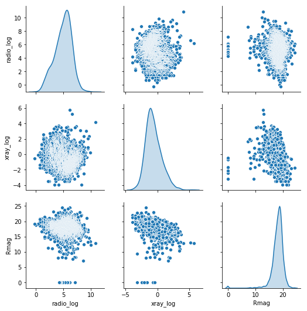

```python
# Let's create two columns with the log of radio/xray fluxes

import numpy as np
bzcat['radio_log'] = np.log(bzcat[col['flux_radio']])
_ind = bzcat[col['flux_radio']] <= 0
bzcat.loc[_ind,'radio_log'] = None

bzcat['xray_log'] = np.log(bzcat[col['flux_xray']])
_ind = bzcat[col['flux_xray']] <= 0
bzcat.loc[_ind,'xray_log'] = None

sns.pairplot(bzcat[['radio_log','xray_log', col['flux_opt']]], diag_kind='kde', kind='scatter')
```

```python
del bzcat['xray_log'],bzcat['radio_log']
```

```python
bzcat['Label'] = bzcat[col['idn']].astype(str) +'_'+ bzcat[col['ra']].astype(str).str.replace('.','_') +'_'+ bzcat[col['dec']].astype(str).str.replace('.','_')
```

```python
bzcat
```

|  | RA (J2000.0) | Dec (J2000.0) | id | Source name | Flux density 1.4/0.843GHz(mJy) | Source classification | Rmag | X-ray flux 0.1-2.4 keV(1.e-12 cgs) | Redshift | Label |
| --- | --- | --- | --- | --- | --- | --- | --- | --- | --- | --- |
| 0 | 187.27792 | 2.05239 | 1923 | 5BZQJ1229+0203 | 54992.0 | QSO RLoud flat radio sp. | 12.9 | 63.10 | 0.158 | 1923_187_27792_2_05239 |
| 1 | 49.95067 | 41.51169 | 508 | 5BZUJ0319+4130 | 22830.0 | Blazar Uncertain type | 12.3 | 0.00 | 0.018 | 508_49_95067_41_51169 |
| 2 | 274.89583 | -63.76339 | 2910 | 5BZUJ1819-6345 | 19532.0 | Blazar Uncertain type | 13.4 | 1.24 | 0.063 | 2910_274_89583_-63_76339 |
| 3 | 80.74158 | -36.45856 | 759 | 5BZUJ0522-3627 | 15620.0 | Blazar Uncertain type | 14.6 | 10.40 | 0.056 | 759_80_74158_-36_45856 |
| 4 | 277.38242 | 48.74617 | 2924 | 5BZUJ1829+4844 | 13753.0 | Blazar Uncertain type | 16.7 | 2.20 | 0.695 | 2924_277_38242_48_74617 |
| 5 | 291.21275 | -29.24169 | 2991 | 5BZQJ1924-2914 | 13387.0 | QSO RLoud flat radio sp. | 17.3 | 2.42 | 0.353 | 2991_291_21275_-29_241690000000002 |
| 6 | 343.49063 | 16.14822 | 3374 | 5BZQJ2253+1608 | 12657.0 | QSO RLoud flat radio sp. | 13.2 | 7.80 | 0.859 | 3374_343_49062999999995_16_148220000000002 |
| 7 | 278.41638 | -21.06103 | 2930 | 5BZQJ1833-2103 | 10896.0 | QSO RLoud flat radio sp. | 21.0 | 0.69 | 2.507 | 2930_278_41638_-21_06103 |
| 8 | 194.04654 | -5.78931 | 2014 | 5BZQJ1256-0547 | 9711.0 | QSO RLoud flat radio sp. | 15.0 | 20.90 | 0.536 | 2014_194_04654_-5_7893099999999995 |
| 9 | 128.72904 | 55.57278 | 1137 | 5BZGJ0834+5534 | 8283.0 | BL Lac-galaxy dominated | 17.2 | 1.21 | 0.242 | 1137_128_72904_55_57278 |
| 10 | 224.78158 | 71.67219 | 2433 | 5BZUJ1459+7140 | 7468.0 | Blazar Uncertain type | 17.2 | 0.77 | 0.91 | 2433_224_78158_71_67219 |
| 11 | 336.44692 | -4.95039 | 3304 | 5BZQJ2225-0457 | 7412.0 | QSO RLoud flat radio sp. | 17.6 | 0.89 | 1.404 | 3304_336_44692000000003_-4_9503900000000005 |
| 12 | 338.15171 | 11.73081 | 3316 | 5BZQJ2232+1143 | 7202.0 | QSO RLoud flat radio sp. | 16.7 | 1.26 | 1.037 | 3316_338_15171000000004_11_73081 |
| 13 | 250.74504 | 39.81028 | 2707 | 5BZQJ1642+3948 | 7099.0 | QSO RLoud flat radio sp. | 15.4 | 2.52 | 0.593 | 2707_250_74504_39_81028 |
| 14 | 331.54342 | -18.59408 | 3258 | 5BZQJ2206-1835 | 6399.0 | QSO RLoud flat radio sp. | 18.5 | 0.08 | 0.619 | 3258_331_54342_-18_594079999999998 |
| 15 | 70.07158 | -43.55239 | 678 | 5BZQJ0440-4333 | 6362.0 | QSO RLoud flat radio sp. | 18.2 | 0.40 | 2.852 | 678_70_07158000000001_-43_55239 |
| 16 | 239.24529 | -79.23453 | 2579 | 5BZQJ1556-7914 | 6165.0 | QSO RLoud flat radio sp. | 17.2 | 0.56 | 0.152 | 2579_239_24528999999998_-79_23453 |
| 17 | 309.65429 | 51.32019 | 3105 | 5BZQJ2038+5119 | 6081.0 | QSO RLoud flat radio sp. | 18.9 | 0.28 | 1.686 | 3105_309_65429_51_320190000000004 |
| 18 | 330.68038 | 42.27778 | 3252 | 5BZBJ2202+4216 | 6051.0 | BL Lac | 12.5 | 10.40 | 0.069 | 3252_330_68037999999996_42_27778 |
| 19 | 263.26129 | -13.08042 | 2821 | 5BZQJ1733-1304 | 5990.0 | QSO RLoud flat radio sp. | 17.8 | 1.64 | 0.902 | 2821_263_26129_-13_08042 |
| 20 | 201.36508 | -43.01911 | 2116 | 5BZUJ1325-4301 | 5700.0 | Blazar Uncertain type | 7.2 | 5.43 | 0.002 | 2116_201_36508_-43_01911 |
| 21 | 115.88171 | -67.44042 | 984 | 5BZQJ0743-6726 | 5638.0 | QSO RLoud flat radio sp. | 15.8 | 0.78 | 1.512 | 984_115_88171000000001_-67_44041999999999 |
| 22 | 172.52938 | -14.82428 | 1710 | 5BZQJ1130-1449 | 5622.0 | QSO RLoud flat radio sp. | 16.0 | 1.39 | 1.184 | 1710_172_52938_-14_824279999999998 |
| 23 | 98.94379 | -75.27133 | 879 | 5BZQJ0635-7516 | 5283.0 | QSO RLoud flat radio sp. | 15.7 | 2.84 | 0.653 | 879_98_94379_-75_27133 |
| 24 | 59.87396 | 50.96394 | 586 | 5BZQJ0359+5057 | 4297.0 | QSO RLoud flat radio sp. | 18.1 | 0.78 | 1.512 | 586_59_87396_50_96394 |
| 25 | 137.38954 | 42.89625 | 1253 | 5BZUJ0909+4253 | 4234.0 | Blazar Uncertain type | 18.8 | 0.40 | 0.67 | 1253_137_38953999999998_42_89625 |
| 26 | 61.39167 | -13.13714 | 600 | 5BZQJ0405-1308 | 4218.0 | QSO RLoud flat radio sp. | 16.6 | 0.97 | 0.571 | 600_61_39167_-13_137139999999999 |
| 27 | 31.21004 | 15.23639 | 327 | 5BZUJ0204+1514 | 4068.0 | Blazar Uncertain type | 22.0 | 0.02 | 0.833 | 327_31_210040000000003_15_23639 |
| 28 | 244.45533 | -77.28847 | 2639 | 5BZQJ1617-7717 | 4044.0 | QSO RLoud flat radio sp. | 16.7 | 0.55 | 1.71 | 2639_244_45532999999998_-77_28846999999999 |
| 29 | 243.42108 | 34.21331 | 2624 | 5BZQJ1613+3412 | 4024.0 | QSO RLoud flat radio sp. | 17.3 | 0.40 | 1.397 | 2624_243_42108_34_21331 |
| ... | ... | ... | ... | ... | ... | ... | ... | ... | ... | ... |
| 3531 | 202.13983 | 11.75569 | 2131 | 5BZBJ1328+1145 | 3.0 | BL Lac | 19.0 | 2.19 | 0.49 | 2131_202_13983000000002_11_75569 |
| 3532 | 224.61396 | 48.54611 | 2430 | 5BZBJ1458+4832 | 3.0 | BL Lac | 19.9 | 3.18 | 0.541 | 2430_224_61396000000002_48_54611 |
| 3533 | 266.63487 | 50.46964 | 2850 | 5BZBJ1746+5028 | 3.0 | BL Lac Candidate | 19.9 | 0.40 | 0 | 2850_266_63487000000003_50_469640000000005 |
| 3534 | 195.73058 | 50.93842 | 2044 | 5BZBJ1302+5056 | 3.0 | BL Lac | 19.5 | 4.04 | 0 | 2044_195_73058_50_93842 |
| 3535 | 259.27871 | 29.52253 | 2783 | 5BZGJ1717+2931 | 3.0 | BL Lac-galaxy dominated | 16.7 | 3.29 | 0.276 | 2783_259_27871_29_52253 |
| 3536 | 202.76213 | 56.92828 | 2142 | 5BZGJ1331+5655 | 3.0 | BL Lac-galaxy dominated | 18.4 | 0.47 | 0.27 | 2142_202_76213_56_92828000000001 |
| 3537 | 260.31913 | 60.06844 | 2796 | 5BZBJ1721+6004 | 3.0 | BL Lac | 19.6 | 0.18 | 0.531 | 2796_260_31913_60_06844 |
| 3538 | 201.38692 | -30.02864 | 2118 | 5BZBJ1325-3001 | 3.0 | BL Lac Candidate | 20.0 | 3.68 | 0 | 2118_201_38692_-30_028640000000003 |
| 3539 | 21.18550 | 9.31369 | 233 | 5BZBJ0124+0918 | 2.0 | BL Lac | 19.1 | 0.21 | 0.338 | 233_21_1855_9_31369 |
| 3540 | 118.84629 | 37.43856 | 1025 | 5BZBJ0755+3726 | 2.0 | BL Lac | 20.7 | 0.73 | 0.606 | 1025_118_84629_37_438559999999995 |
| 3541 | 150.42671 | 20.80506 | 1404 | 5BZGJ1001+2048 | 2.0 | BL Lac-galaxy dominated | 19.3 | 0.17 | 0.344 | 1404_150_42671_20_80506 |
| 3542 | 146.13471 | 57.59336 | 1350 | 5BZBJ0944+5735 | 2.0 | BL Lac | 19.7 | 1.27 | 0 | 1350_146_13471_57_59336 |
| 3543 | 259.75975 | 55.40178 | 2789 | 5BZBJ1719+5524 | 2.0 | BL Lac | 20.8 | 0.26 | 0.626 | 2789_259_75975_55_40178 |
| 3544 | 258.68975 | 30.60778 | 2775 | 5BZBJ1714+3036 | 2.0 | BL Lac | 18.6 | 0.25 | 0 | 2775_258_68975_30_607779999999998 |
| 3545 | 129.94750 | 2.07614 | 1156 | 5BZUJ0839+0204 | 2.0 | Blazar Uncertain type | 20.6 | 0.00 | 0 | 1156_129_9475_2_07614 |
| 3546 | 5.50396 | 0.11611 | 64 | 5BZGJ0022+0006 | 2.0 | BL Lac-galaxy dominated | 18.6 | 1.01 | 0.306 | 64_5_50396_0_11610999999999999 |
| 3547 | 187.03808 | -2.36006 | 1918 | 5BZBJ1228-0221 | 1.5 | BL Lac | 19.1 | 0.93 | 0.323 | 1918_187_03808_-2_36006 |
| 3548 | 353.70129 | -8.57706 | 3489 | 5BZBJ2334-0834 | 1.0 | BL Lac Candidate | 18.8 | 0.00 | 0.208 | 3489_353_70129_-8_577060000000001 |
| 3549 | 192.10792 | 8.50583 | 1986 | 5BZBJ1248+0830 | 0.8 | BL Lac | 19.2 | 0.57 | 0.43 | 1986_192_10792_8_50583 |
| 3550 | 228.66675 | -47.80831 | 2480 | 5BZQJ1514-4748 | 0.0 | QSO RLoud flat radio sp. | 18.4 | 0.00 | 1.551 | 2480_228_66675_-47_80831 |
| 3551 | 202.25475 | -56.13406 | 2132 | 5BZUJ1329-5608 | 0.0 | Blazar Uncertain type | 0.0 | 0.63 | 0 | 2132_202_25475_-56_13406 |
| 3552 | 356.34317 | -15.25186 | 3511 | 5BZUJ2345-1515 | 0.0 | Blazar Uncertain type | 19.4 | 0.25 | 0 | 3511_356_34317000000004_-15_25186 |
| 3553 | 252.56929 | -50.74672 | 2721 | 5BZUJ1650-5044 | 0.0 | Blazar Uncertain type | 0.0 | 0.00 | 0 | 2721_252_56929_-50_74672 |
| 3554 | 131.45700 | -55.92408 | 1171 | 5BZQJ0845-5555 | 0.0 | QSO RLoud flat radio sp. | 19.8 | 0.00 | 0.433 | 1171_131_457_-55_924080000000004 |
| 3555 | 98.83712 | -26.34442 | 878 | 5BZBJ0635-2620 | 0.0 | BL Lac | 19.1 | 0.00 | 0 | 878_98_83712_-26_34442 |
| 3556 | 198.76738 | -53.57661 | 2083 | 5BZUJ1315-5334 | 0.0 | Blazar Uncertain type | 18.3 | 0.00 | 0 | 2083_198_76738_-53_576609999999995 |
| 3557 | 160.43600 | -47.66669 | 1541 | 5BZQJ1041-4740 | 0.0 | QSO RLoud flat radio sp. | 17.2 | 0.25 | 2.558 | 1541_160_436_-47_66669 |
| 3558 | 201.70508 | -52.93989 | 2123 | 5BZBJ1326-5256 | 0.0 | BL Lac | 15.8 | 0.26 | 0 | 2123_201_70508_-52_939890000000005 |
| 3559 | 259.39438 | -51.92556 | 2786 | 5BZQJ1717-5155 | 0.0 | QSO RLoud flat radio sp. | 18.3 | 0.00 | 1.158 | 2786_259_39437999999996_-51_92556 |
| 3560 | 241.12925 | -44.69222 | 2598 | 5BZBJ1604-4441 | 0.0 | BL Lac | 20.0 | 0.44 | 0 | 2598_241_12925_-44_69222 |

3561 rows × 10 columns

```python
bzcat[['Label', col['ra'], col['dec']]].to_csv('5bzcat_Label_Ra_Dec.csv', index=False, sep=" ", float_format='%.5f')
```

```python
from subprocess import getoutput
print(getoutput('head 5bzcat_Label_Ra_Dec.csv'))
```

```
Label "RA (J2000.0)" "Dec (J2000.0)"
1923_187_27792_2_05239 187.27792 2.05239
508_49_95067_41_51169 49.95067 41.51169
2910_274_89583_-63_76339 274.89583 -63.76339
759_80_74158_-36_45856 80.74158 -36.45856
2924_277_38242_48_74617 277.38242 48.74617
2991_291_21275_-29_241690000000002 291.21275 -29.24169
3374_343_49062999999995_16_148220000000002 343.49063 16.14822
2930_278_41638_-21_06103 278.41638 -21.06103
2014_194_04654_-5_7893099999999995 194.04654 -5.78931
```

```python
cols_reord = bzcat.columns
cols_reord = [cols_reord[i-1] for i in range(len(cols_reord))]

bzcat = bzcat[cols_reord]
bzcat.head()
```

|  | Label | RA (J2000.0) | Dec (J2000.0) | id | Source name | Flux density 1.4/0.843GHz(mJy) | Source classification | Rmag | X-ray flux 0.1-2.4 keV(1.e-12 cgs) | Redshift |
| --- | --- | --- | --- | --- | --- | --- | --- | --- | --- | --- |
| 0 | 1923_187_27792_2_05239 | 187.27792 | 2.05239 | 1923 | 5BZQJ1229+0203 | 54992.0 | QSO RLoud flat radio sp. | 12.9 | 63.10 | 0.158 |
| 1 | 508_49_95067_41_51169 | 49.95067 | 41.51169 | 508 | 5BZUJ0319+4130 | 22830.0 | Blazar Uncertain type | 12.3 | 0.00 | 0.018 |
| 2 | 2910_274_89583_-63_76339 | 274.89583 | -63.76339 | 2910 | 5BZUJ1819-6345 | 19532.0 | Blazar Uncertain type | 13.4 | 1.24 | 0.063 |
| 3 | 759_80_74158_-36_45856 | 80.74158 | -36.45856 | 759 | 5BZUJ0522-3627 | 15620.0 | Blazar Uncertain type | 14.6 | 10.40 | 0.056 |
| 4 | 2924_277_38242_48_74617 | 277.38242 | 48.74617 | 2924 | 5BZUJ1829+4844 | 13753.0 | Blazar Uncertain type | 16.7 | 2.20 | 0.695 |

## Spectra retrieval

At this point, the SED of each object (providing one) is built from `VOU-Blazars` (`VOUB` hereafter). Results of `VOUB` are placed in `./work/bzcat/Results`, in particular the SEDs go inside `SEDtool/` in that dir.

```python
%ls work/bzcat/Results/
```

[output not shown]

[output cut: 1133 more lines]

```
2057_197_09879_35_777/    3126_313_84742_-5_10536/  990_116_47533_-0_73819/
2058_197_21388_47_49858/  3127_313_86758_-0_35478/  991_116_49658_22_44747/
2059_197_29063_55_96064/  3128_314_06817_-47_24656/ 992_116_49717_33_22614/
205_18_71988_13_42708/    3129_314_10446_-32_14661/ 993_116_576_-15_92631/
2060_197_35638_43_08489/  312_29_89329_10_78486/    994_116_60779_25_81725/
2061_197_39138_11_90683/  3130_314_22879_-38_95461/ 995_116_74258_-56_30931/
2062_197_452_-39_80919/   3131_314_42333_-37_5675/  996_116_77083_-67_74453/
2063_197_55204_-11_96289/ 3132_314_91075_-0_63222/  997_116_81087_76_65481/
2064_197_61875_0_73581/   3133_315_25692_-29_55772/ 998_116_84258_9_09814/
2065_197_61942_32_3455/   3134_315_41179_3_69203/   999_117_05279_-52_9755/
2066_197_72329_46_89783/  3135_315_66758_60_25272/  99_9_58663_-3_49967/
2067_197_7475_32_55956/   3136_315_90079_-68_20078/ 9_1_02033_-11_81611/
2068_197_76338_55_23175/  3137_316_25483_-48_81292/ SEDtool/
2069_197_77696_0_58611/   3138_316_54508_21_59333/
206_18_75717_-34_00756/   3139_316_61729_2_52717/
```

```python
%ls work/bzcat/Results/SEDtool/
```

[output not shown]

[output cut: 1726 more lines]

```
229_23660_19_53692_sedtool.txt   99_83704_m33_76669_sedtool.txt
229_32146_13_54011_sedtool.txt   99_84121_73_41619_sedtool.txt
229_42438_m24_37222_sedtool.txt  9_02896_m9_54156_sedtool.txt
229_44812_65_42322_sedtool.txt   9_31175_m21_75686_sedtool.txt
229_66216_40_75003_sedtool.txt   9_34804_21_69814_sedtool.txt
22_03362_49_01844_sedtool.txt    9_46192_12_63884_sedtool.txt
22_17221_44_65500_sedtool.txt    9_53533_0_22683_sedtool.txt
22_53712_m10_31872_sedtool.txt   9_56142_m24_98389_sedtool.txt
22_61517_8_71283_sedtool.txt     9_58666_m3_49971_sedtool.txt
22_77983_61_34250_sedtool.txt    9_60346_41_61839_sedtool.txt
22_86125_38_57756_sedtool.txt    9_62029_18_93825_sedtool.txt
230_14578_55_71578_sedtool.txt   9_77617_m9_71300_sedtool.txt
230_16570_42_18658_sedtool.txt   9_88163_m11_18414_sedtool.txt
230_18941_7_54212_sedtool.txt    9_91500_14_19931_sedtool.txt
230_20395_m3_81427_sedtool.txt
```

## Recover results

To read the resulting SEDs, for each object, we may have to do some small processing on the RA/Dec values of each object to properly relate to the data/SED files. The reason is the name convention used used in the output files:

- directories in `Results/` are named after the given/input RA and Dec values; on the other hand,
- directories in `Results/SEDtool/` are named after the object's (assumed) Radio source position.

```python
#ra_s1 = bzcat[col['ra']].apply(lambda x:'{:.5f}'.format(x)).str.replace('.','_')
ra_s1 = bzcat[col['ra']].astype(str)
ra_s1 = [s.split('.') for s in ra_s1]
ra_s1 = ['_'.join([l[0],l[1][:3]]) for l in ra_s1]

#dec_s1 = bzcat[col['dec']].apply(lambda x:'{:.5f}'.format(x)).str.replace('.','_').str.replace('-','m')
dec_s1 = bzcat[col['dec']].astype(str)
dec_s1 = [s.split('.') for s in dec_s1]
dec_s1 = ['_'.join([l[0],l[1][:3]]).replace('-','m') for l in dec_s1]

ids = bzcat['Label']
```

```python
from os import path
from glob import glob
seds = [path.basename(p) for p in glob('work/bzcat/Results/SEDtool/*_sedtool.txt')]
seds_filename = seds[:]

seds = [s.replace('_sedtool.txt','') for s in seds]

seds = [s.split('_') for s in seds]

ra_s2 = ['_'.join([l[0],l[1][:3]]) for l in seds]

dec_s2 = ['_'.join([l[2],l[3][:3]]) for l in seds]
```

```python
df1 = pd.DataFrame(data={'ra_1':ra_s1, 'dec_1':dec_s1, 'ids':ids})

df2 = pd.DataFrame(data={'ra_2':ra_s2, 'dec_2':dec_s2, 'filenames':seds_filename})
```

```python
df1.head()
```

|  | ra_1 | dec_1 | ids |
| --- | --- | --- | --- |
| 0 | 187_277 | 2_052 | 1923_187_27792_2_05239 |
| 1 | 49_950 | 41_511 | 508_49_95067_41_51169 |
| 2 | 274_895 | m63_763 | 2910_274_89583_-63_76339 |
| 3 | 80_741 | m36_458 | 759_80_74158_-36_45856 |
| 4 | 277_382 | 48_746 | 2924_277_38242_48_74617 |

```python
df2.head()
```

|  | ra_2 | dec_2 | filenames |
| --- | --- | --- | --- |
| 0 | 0_084 | m32_349 | 0_08471_m32_34972_sedtool.txt |
| 1 | 0_272 | m15_851 | 0_27204_m15_85194_sedtool.txt |
| 2 | 0_285 | 19_242 | 0_28596_19_24286_sedtool.txt |
| 3 | 0_325 | m7_774 | 0_32511_m7_77410_sedtool.txt |
| 4 | 0_339 | m0_194 | 0_33950_m0_19442_sedtool.txt |

```python
df1['radec1'] = df1.apply(lambda x:'_'.join([x['ra_1'],x['dec_1']]), axis=1)
# df1.sort_values(['ra_1','dec_1'], inplace=True)
```

```python
df2['radec2'] = df2.apply(lambda x:'_'.join([x['ra_2'],x['dec_2']]), axis=1)
# df2.sort_values(['ra_2','dec_2'], inplace=True)
```

```python
df3 = df1.merge(df2, left_on='radec1', right_on='radec2', how='inner')
df3
```

|  | ra_1 | dec_1 | ids | radec1 | ra_2 | dec_2 | filenames | radec2 |
| --- | --- | --- | --- | --- | --- | --- | --- | --- |
| 0 | 49_950 | 41_511 | 508_49_95067_41_51169 | 49_950_41_511 | 49_950 | 41_511 | 49_95067_41_51169_sedtool.txt | 49_950_41_511 |
| 1 | 80_741 | m36_458 | 759_80_74158_-36_45856 | 80_741_m36_458 | 80_741 | m36_458 | 80_74179_m36_45833_sedtool.txt | 80_741_m36_458 |
| 2 | 277_382 | 48_746 | 2924_277_38242_48_74617 | 277_382_48_746 | 277_382 | 48_746 | 277_38250_48_74631_sedtool.txt | 277_382_48_746 |
| 3 | 291_212 | m29_241 | 2991_291_21275_-29_241690000000002 | 291_212_m29_241 | 291_212 | m29_241 | 291_21296_m29_24194_sedtool.txt | 291_212_m29_241 |
| 4 | 343_490 | 16_148 | 3374_343_49062999999995_16_148220000000002 | 343_490_16_148 | 343_490 | 16_148 | 343_49042_16_14817_sedtool.txt | 343_490_16_148 |
| 5 | 278_416 | m21_061 | 2930_278_41638_-21_06103 | 278_416_m21_061 | 278_416 | m21_061 | 278_41658_m21_06108_sedtool.txt | 278_416_m21_061 |
| 6 | 224_781 | 71_672 | 2433_224_78158_71_67219 | 224_781_71_672 | 224_781 | 71_672 | 224_78179_71_67219_sedtool.txt | 224_781_71_672 |
| 7 | 338_151 | 11_730 | 3316_338_15171000000004_11_73081 | 338_151_11_730 | 338_151 | 11_730 | 338_15162_11_73080_sedtool.txt | 338_151_11_730 |
| 8 | 331_543 | m18_594 | 3258_331_54342_-18_594079999999998 | 331_543_m18_594 | 331_543 | m18_594 | 331_54304_m18_59417_sedtool.txt | 331_543_m18_594 |
| 9 | 70_071 | m43_552 | 678_70_07158000000001_-43_55239 | 70_071_m43_552 | 70_071 | m43_552 | 70_07112_m43_55250_sedtool.txt | 70_071_m43_552 |
| 10 | 309_654 | 51_320 | 3105_309_65429_51_320190000000004 | 309_654_51_320 | 309_654 | 51_320 | 309_65421_51_32031_sedtool.txt | 309_654_51_320 |
| 11 | 330_680 | 42_277 | 3252_330_68037999999996_42_27778 | 330_680_42_277 | 330_680 | 42_277 | 330_68038_42_27781_sedtool.txt | 330_680_42_277 |
| 12 | 263_261 | m13_080 | 2821_263_26129_-13_08042 | 263_261_m13_080 | 263_261 | m13_080 | 263_26108_m13_08031_sedtool.txt | 263_261_m13_080 |
| 13 | 172_529 | m14_824 | 1710_172_52938_-14_824279999999998 | 172_529_m14_824 | 172_529 | m14_824 | 172_52938_m14_82422_sedtool.txt | 172_529_m14_824 |
| 14 | 137_389 | 42_896 | 1253_137_38953999999998_42_89625 | 137_389_42_896 | 137_389 | 42_896 | 137_38957_42_89626_sedtool.txt | 137_389_42_896 |
| 15 | 61_391 | m13_137 | 600_61_39167_-13_137139999999999 | 61_391_m13_137 | 61_391 | m13_137 | 61_39142_m13_13733_sedtool.txt | 61_391_m13_137 |
| 16 | 31_210 | 15_236 | 327_31_210040000000003_15_23639 | 31_210_15_236 | 31_210 | 15_236 | 31_21000_15_23644_sedtool.txt | 31_210_15_236 |
| 17 | 243_421 | 34_213 | 2624_243_42108_34_21331 | 243_421_34_213 | 243_421 | 34_213 | 243_42107_34_21329_sedtool.txt | 243_421_34_213 |
| 18 | 291_952 | 73_967 | 2999_291_95207999999997_73_96710999999999 | 291_952_73_967 | 291_952 | 73_967 | 291_95221_73_96725_sedtool.txt | 291_952_73_967 |
| 19 | 227_723 | m5_718 | 2470_227_72329_-5_718719999999999 | 227_723_m5_718 | 227_723 | m5_718 | 227_72330_m5_71858_sedtool.txt | 227_723_m5_718 |
| 20 | 116_387 | 10_186 | 989_116_38775_10_186860000000001 | 116_387_10_186 | 116_387 | 10_186 | 116_38792_10_18692_sedtool.txt | 116_387_10_186 |
| 21 | 32_692 | m51_017 | 345_32_6925_-51_01719 | 32_692_m51_017 | 32_692 | m51_017 | 32_69200_m51_01728_sedtool.txt | 32_692_m51_017 |
| 22 | 324_160 | 0_698 | 3187_324_16078999999996_0_69839 | 324_160_0_698 | 324_160 | 0_698 | 324_16074_0_69843_sedtool.txt | 324_160_0_698 |
| 23 | 216_984 | m42_105 | 2337_216_98458_-42_10539 | 216_984_m42_105 | 216_984 | m42_105 | 216_98425_m42_10517_sedtool.txt | 216_984_m42_105 |
| 24 | 352_323 | m47_505 | 3475_352_32375_-47_505309999999994 | 352_323_m47_505 | 352_323 | m47_505 | 352_32392_m47_50533_sedtool.txt | 352_323_m47_505 |
| 25 | 329_526 | m15_019 | 3242_329_52617000000004_-15_01925 | 329_526_m15_019 | 329_526 | m15_019 | 329_52625_m15_01919_sedtool.txt | 329_526_m15_019 |
| 26 | 240_530 | 33_448 | 2590_240_53025_33_44808 | 240_530_33_448 | 240_530 | 33_448 | 240_53025_33_44808_sedtool.txt | 240_530_33_448 |
| 27 | 135_570 | m14_258 | 1225_135_57012_-14_258579999999998 | 135_570_m14_258 | 135_570 | m14_258 | 135_57021_m14_25844_sedtool.txt | 135_570_m14_258 |
| 28 | 141_762 | 39_039 | 1306_141_76254_39_03914 | 141_762_39_039 | 141_762 | 39_039 | 141_76260_39_03909_sedtool.txt | 141_762_39_039 |
| 29 | 330_812 | 31_760 | 3254_330_81242000000003_31_760640000000002 | 330_812_31_760 | 330_812 | 31_760 | 330_81217_31_76075_sedtool.txt | 330_812_31_760 |
| ... | ... | ... | ... | ... | ... | ... | ... | ... |
| 2656 | 202_008 | 11_487 | 2130_202_00871_11_487110000000001 | 202_008_11_487 | 202_008 | 11_487 | 202_00871_11_48715_sedtool.txt | 202_008_11_487 |
| 2657 | 155_370 | 38_112 | 1470_155_37028999999998_38_11203 | 155_370_38_112 | 155_370 | 38_112 | 155_37038_38_11204_sedtool.txt | 155_370_38_112 |
| 2658 | 118_352 | 29_358 | 1018_118_35253999999999_29_358859999999996 | 118_352_29_358 | 118_352 | 29_358 | 118_35250_29_35886_sedtool.txt | 118_352_29_358 |
| 2659 | 111_178 | 26_358 | 939_111_17808000000001_26_3585 | 111_178_26_358 | 111_178 | 26_358 | 111_17804_26_35850_sedtool.txt | 111_178_26_358 |
| 2660 | 117_937 | 39_471 | 1014_117_93725_39_47156 | 117_937_39_471 | 117_937 | 39_471 | 117_93725_39_47156_sedtool.txt | 117_937_39_471 |
| 2661 | 128_214 | 33_003 | 1129_128_21442_33_00306 | 128_214_33_003 | 128_214 | 33_003 | 128_21447_33_00301_sedtool.txt | 128_214_33_003 |
| 2662 | 347_828 | m9_772 | 3424_347_82825_-9_77289 | 347_828_m9_772 | 347_828 | m9_772 | 347_82871_m9_77293_sedtool.txt | 347_828_m9_772 |
| 2663 | 242_514 | 45_278 | 2617_242_514_45_27828 | 242_514_45_278 | 242_514 | 45_278 | 242_51416_45_27822_sedtool.txt | 242_514_45_278 |
| 2664 | 170_549 | 43_280 | 1687_170_54921000000002_43_28047 | 170_549_43_280 | 170_549 | 43_280 | 170_54926_43_28040_sedtool.txt | 170_549_43_280 |
| 2665 | 143_294 | 0_056 | 1327_143_29404_0_05653 | 143_294_0_056 | 143_294 | 0_056 | 143_29406_0_05666_sedtool.txt | 143_294_0_056 |
| 2666 | 202_139 | 11_755 | 2131_202_13983000000002_11_75569 | 202_139_11_755 | 202_139 | 11_755 | 202_13989_11_75565_sedtool.txt | 202_139_11_755 |
| 2667 | 195_730 | 50_938 | 2044_195_73058_50_93842 | 195_730_50_938 | 195_730 | 50_938 | 195_73080_50_93842_sedtool.txt | 195_730_50_938 |
| 2668 | 202_762 | 56_928 | 2142_202_76213_56_92828000000001 | 202_762_56_928 | 202_762 | 56_928 | 202_76210_56_92836_sedtool.txt | 202_762_56_928 |
| 2669 | 260_319 | 60_068 | 2796_260_31913_60_06844 | 260_319_60_068 | 260_319 | 60_068 | 260_31913_60_06844_sedtool.txt | 260_319_60_068 |
| 2670 | 21_185 | 9_313 | 233_21_1855_9_31369 | 21_185_9_313 | 21_185 | 9_313 | 21_18550_9_31369_sedtool.txt | 21_185_9_313 |
| 2671 | 118_846 | 37_438 | 1025_118_84629_37_438559999999995 | 118_846_37_438 | 118_846 | 37_438 | 118_84626_37_43839_sedtool.txt | 118_846_37_438 |
| 2672 | 146_134 | 57_593 | 1350_146_13471_57_59336 | 146_134_57_593 | 146_134 | 57_593 | 146_13433_57_59338_sedtool.txt | 146_134_57_593 |
| 2673 | 129_947 | 2_076 | 1156_129_9475_2_07614 | 129_947_2_076 | 129_947 | 2_076 | 129_94746_2_07614_sedtool.txt | 129_947_2_076 |
| 2674 | 187_038 | m2_360 | 1918_187_03808_-2_36006 | 187_038_m2_360 | 187_038 | m2_360 | 187_03812_m2_36030_sedtool.txt | 187_038_m2_360 |
| 2675 | 353_701 | m8_577 | 3489_353_70129_-8_577060000000001 | 353_701_m8_577 | 353_701 | m8_577 | 353_70125_m8_57706_sedtool.txt | 353_701_m8_577 |
| 2676 | 192_107 | 8_505 | 1986_192_10792_8_50583 | 192_107_8_505 | 192_107 | 8_505 | 192_10792_8_50583_sedtool.txt | 192_107_8_505 |
| 2677 | 228_666 | m47_808 | 2480_228_66675_-47_80831 | 228_666_m47_808 | 228_666 | m47_808 | 228_66675_m47_80831_sedtool.txt | 228_666_m47_808 |
| 2678 | 202_254 | m56_134 | 2132_202_25475_-56_13406 | 202_254_m56_134 | 202_254 | m56_134 | 202_25475_m56_13406_sedtool.txt | 202_254_m56_134 |
| 2679 | 356_343 | m15_251 | 3511_356_34317000000004_-15_25186 | 356_343_m15_251 | 356_343 | m15_251 | 356_34317_m15_25186_sedtool.txt | 356_343_m15_251 |
| 2680 | 252_569 | m50_746 | 2721_252_56929_-50_74672 | 252_569_m50_746 | 252_569 | m50_746 | 252_56925_m50_74672_sedtool.txt | 252_569_m50_746 |
| 2681 | 98_837 | m26_344 | 878_98_83712_-26_34442 | 98_837_m26_344 | 98_837 | m26_344 | 98_83708_m26_34442_sedtool.txt | 98_837_m26_344 |
| 2682 | 198_767 | m53_576 | 2083_198_76738_-53_576609999999995 | 198_767_m53_576 | 198_767 | m53_576 | 198_76738_m53_57661_sedtool.txt | 198_767_m53_576 |
| 2683 | 201_705 | m52_939 | 2123_201_70508_-52_939890000000005 | 201_705_m52_939 | 201_705 | m52_939 | 201_70504_m52_93989_sedtool.txt | 201_705_m52_939 |
| 2684 | 259_394 | m51_925 | 2786_259_39437999999996_-51_92556 | 259_394_m51_925 | 259_394 | m51_925 | 259_39438_m51_92556_sedtool.txt | 259_394_m51_925 |
| 2685 | 241_129 | m44_692 | 2598_241_12925_-44_69222 | 241_129_m44_692 | 241_129 | m44_692 | 241_12925_m44_69222_sedtool.txt | 241_129_m44_692 |

2686 rows × 8 columns

```python
bzcat_results = bzcat.merge(df3[['ids','filenames']], left_on='Label', right_on='ids')
bzcat_results
```

|  | Label | RA (J2000.0) | Dec (J2000.0) | id | Source name | Flux density 1.4/0.843GHz(mJy) | Source classification | Rmag | X-ray flux 0.1-2.4 keV(1.e-12 cgs) | Redshift | ids | filenames |
| --- | --- | --- | --- | --- | --- | --- | --- | --- | --- | --- | --- | --- |
| 0 | 508_49_95067_41_51169 | 49.95067 | 41.51169 | 508 | 5BZUJ0319+4130 | 22830.0 | Blazar Uncertain type | 12.3 | 0.00 | 0.018 | 508_49_95067_41_51169 | 49_95067_41_51169_sedtool.txt |
| 1 | 759_80_74158_-36_45856 | 80.74158 | -36.45856 | 759 | 5BZUJ0522-3627 | 15620.0 | Blazar Uncertain type | 14.6 | 10.40 | 0.056 | 759_80_74158_-36_45856 | 80_74179_m36_45833_sedtool.txt |
| 2 | 2924_277_38242_48_74617 | 277.38242 | 48.74617 | 2924 | 5BZUJ1829+4844 | 13753.0 | Blazar Uncertain type | 16.7 | 2.20 | 0.695 | 2924_277_38242_48_74617 | 277_38250_48_74631_sedtool.txt |
| 3 | 2991_291_21275_-29_241690000000002 | 291.21275 | -29.24169 | 2991 | 5BZQJ1924-2914 | 13387.0 | QSO RLoud flat radio sp. | 17.3 | 2.42 | 0.353 | 2991_291_21275_-29_241690000000002 | 291_21296_m29_24194_sedtool.txt |
| 4 | 3374_343_49062999999995_16_148220000000002 | 343.49063 | 16.14822 | 3374 | 5BZQJ2253+1608 | 12657.0 | QSO RLoud flat radio sp. | 13.2 | 7.80 | 0.859 | 3374_343_49062999999995_16_148220000000002 | 343_49042_16_14817_sedtool.txt |
| 5 | 2930_278_41638_-21_06103 | 278.41638 | -21.06103 | 2930 | 5BZQJ1833-2103 | 10896.0 | QSO RLoud flat radio sp. | 21.0 | 0.69 | 2.507 | 2930_278_41638_-21_06103 | 278_41658_m21_06108_sedtool.txt |
| 6 | 2433_224_78158_71_67219 | 224.78158 | 71.67219 | 2433 | 5BZUJ1459+7140 | 7468.0 | Blazar Uncertain type | 17.2 | 0.77 | 0.91 | 2433_224_78158_71_67219 | 224_78179_71_67219_sedtool.txt |
| 7 | 3316_338_15171000000004_11_73081 | 338.15171 | 11.73081 | 3316 | 5BZQJ2232+1143 | 7202.0 | QSO RLoud flat radio sp. | 16.7 | 1.26 | 1.037 | 3316_338_15171000000004_11_73081 | 338_15162_11_73080_sedtool.txt |
| 8 | 3258_331_54342_-18_594079999999998 | 331.54342 | -18.59408 | 3258 | 5BZQJ2206-1835 | 6399.0 | QSO RLoud flat radio sp. | 18.5 | 0.08 | 0.619 | 3258_331_54342_-18_594079999999998 | 331_54304_m18_59417_sedtool.txt |
| 9 | 678_70_07158000000001_-43_55239 | 70.07158 | -43.55239 | 678 | 5BZQJ0440-4333 | 6362.0 | QSO RLoud flat radio sp. | 18.2 | 0.40 | 2.852 | 678_70_07158000000001_-43_55239 | 70_07112_m43_55250_sedtool.txt |
| 10 | 3105_309_65429_51_320190000000004 | 309.65429 | 51.32019 | 3105 | 5BZQJ2038+5119 | 6081.0 | QSO RLoud flat radio sp. | 18.9 | 0.28 | 1.686 | 3105_309_65429_51_320190000000004 | 309_65421_51_32031_sedtool.txt |
| 11 | 3252_330_68037999999996_42_27778 | 330.68038 | 42.27778 | 3252 | 5BZBJ2202+4216 | 6051.0 | BL Lac | 12.5 | 10.40 | 0.069 | 3252_330_68037999999996_42_27778 | 330_68038_42_27781_sedtool.txt |
| 12 | 2821_263_26129_-13_08042 | 263.26129 | -13.08042 | 2821 | 5BZQJ1733-1304 | 5990.0 | QSO RLoud flat radio sp. | 17.8 | 1.64 | 0.902 | 2821_263_26129_-13_08042 | 263_26108_m13_08031_sedtool.txt |
| 13 | 1710_172_52938_-14_824279999999998 | 172.52938 | -14.82428 | 1710 | 5BZQJ1130-1449 | 5622.0 | QSO RLoud flat radio sp. | 16.0 | 1.39 | 1.184 | 1710_172_52938_-14_824279999999998 | 172_52938_m14_82422_sedtool.txt |
| 14 | 1253_137_38953999999998_42_89625 | 137.38954 | 42.89625 | 1253 | 5BZUJ0909+4253 | 4234.0 | Blazar Uncertain type | 18.8 | 0.40 | 0.67 | 1253_137_38953999999998_42_89625 | 137_38957_42_89626_sedtool.txt |
| 15 | 600_61_39167_-13_137139999999999 | 61.39167 | -13.13714 | 600 | 5BZQJ0405-1308 | 4218.0 | QSO RLoud flat radio sp. | 16.6 | 0.97 | 0.571 | 600_61_39167_-13_137139999999999 | 61_39142_m13_13733_sedtool.txt |
| 16 | 327_31_210040000000003_15_23639 | 31.21004 | 15.23639 | 327 | 5BZUJ0204+1514 | 4068.0 | Blazar Uncertain type | 22.0 | 0.02 | 0.833 | 327_31_210040000000003_15_23639 | 31_21000_15_23644_sedtool.txt |
| 17 | 2624_243_42108_34_21331 | 243.42108 | 34.21331 | 2624 | 5BZQJ1613+3412 | 4024.0 | QSO RLoud flat radio sp. | 17.3 | 0.40 | 1.397 | 2624_243_42108_34_21331 | 243_42107_34_21329_sedtool.txt |
| 18 | 2999_291_95207999999997_73_96710999999999 | 291.95208 | 73.96711 | 2999 | 5BZQJ1927+7358 | 3950.0 | QSO RLoud flat radio sp. | 15.2 | 3.66 | 0.302 | 2999_291_95207999999997_73_96710999999999 | 291_95221_73_96725_sedtool.txt |
| 19 | 2470_227_72329_-5_718719999999999 | 227.72329 | -5.71872 | 2470 | 5BZQJ1510-0543 | 3570.0 | QSO RLoud flat radio sp. | 16.9 | 0.42 | 1.191 | 2470_227_72329_-5_718719999999999 | 227_72330_m5_71858_sedtool.txt |
| 20 | 989_116_38775_10_186860000000001 | 116.38775 | 10.18686 | 989 | 5BZQJ0745+1011 | 3506.0 | QSO RLoud flat radio sp. | 21.9 | 0.26 | 2.624 | 989_116_38775_10_186860000000001 | 116_38792_10_18692_sedtool.txt |
| 21 | 345_32_6925_-51_01719 | 32.69250 | -51.01719 | 345 | 5BZUJ0210-5101 | 3493.0 | Blazar Uncertain type | 14.8 | 0.75 | 1.003 | 345_32_6925_-51_01719 | 32_69200_m51_01728_sedtool.txt |
| 22 | 3187_324_16078999999996_0_69839 | 324.16079 | 0.69839 | 3187 | 5BZQJ2136+0041 | 3473.0 | QSO RLoud flat radio sp. | 16.8 | 0.98 | 1.941 | 3187_324_16078999999996_0_69839 | 324_16074_0_69843_sedtool.txt |
| 23 | 2337_216_98458_-42_10539 | 216.98458 | -42.10539 | 2337 | 5BZQJ1427-4206 | 3190.0 | QSO RLoud flat radio sp. | 16.6 | 0.82 | 1.522 | 2337_216_98458_-42_10539 | 216_98425_m42_10517_sedtool.txt |
| 24 | 3475_352_32375_-47_505309999999994 | 352.32375 | -47.50531 | 3475 | 5BZQJ2329-4730 | 3180.0 | QSO RLoud flat radio sp. | 16.5 | 1.84 | 1.302 | 3475_352_32375_-47_505309999999994 | 352_32392_m47_50533_sedtool.txt |
| 25 | 3242_329_52617000000004_-15_01925 | 329.52617 | -15.01925 | 3242 | 5BZQJ2158-1501 | 3021.0 | QSO RLoud flat radio sp. | 17.3 | 0.81 | 0.672 | 3242_329_52617000000004_-15_01925 | 329_52625_m15_01919_sedtool.txt |
| 26 | 2590_240_53025_33_44808 | 240.53025 | 33.44808 | 2590 | 5BZUJ1602+3326 | 2991.0 | Blazar Uncertain type | 23.0 | 0.16 | 1.1 | 2590_240_53025_33_44808 | 240_53025_33_44808_sedtool.txt |
| 27 | 1225_135_57012_-14_258579999999998 | 135.57012 | -14.25858 | 1225 | 5BZQJ0902-1415 | 2898.0 | QSO RLoud flat radio sp. | 16.4 | 0.65 | 1.333 | 1225_135_57012_-14_258579999999998 | 135_57021_m14_25844_sedtool.txt |
| 28 | 1306_141_76254_39_03914 | 141.76254 | 39.03914 | 1306 | 5BZQJ0927+3902 | 2885.0 | QSO RLoud flat radio sp. | 16.6 | 2.13 | 0.695 | 1306_141_76254_39_03914 | 141_76260_39_03909_sedtool.txt |
| 29 | 3254_330_81242000000003_31_760640000000002 | 330.81242 | 31.76064 | 3254 | 5BZQJ2203+3145 | 2878.0 | QSO RLoud flat radio sp. | 14.3 | 3.22 | 0.295 | 3254_330_81242000000003_31_760640000000002 | 330_81217_31_76075_sedtool.txt |
| ... | ... | ... | ... | ... | ... | ... | ... | ... | ... | ... | ... | ... |
| 2656 | 2130_202_00871_11_487110000000001 | 202.00871 | 11.48711 | 2130 | 5BZBJ1328+1129 | 4.0 | BL Lac | 18.5 | 0.27 | 0 | 2130_202_00871_11_487110000000001 | 202_00871_11_48715_sedtool.txt |
| 2657 | 1470_155_37028999999998_38_11203 | 155.37029 | 38.11203 | 1470 | 5BZBJ1021+3806 | 4.0 | BL Lac | 19.8 | 0.24 | 0.467 | 1470_155_37028999999998_38_11203 | 155_37038_38_11204_sedtool.txt |
| 2658 | 1018_118_35253999999999_29_358859999999996 | 118.35254 | 29.35886 | 1018 | 5BZGJ0753+2921 | 4.0 | BL Lac-galaxy dominated | 17.2 | 1.29 | 0.161 | 1018_118_35253999999999_29_358859999999996 | 118_35250_29_35886_sedtool.txt |
| 2659 | 939_111_17808000000001_26_3585 | 111.17808 | 26.35850 | 939 | 5BZBJ0724+2621 | 4.0 | BL Lac Candidate | 17.4 | 0.00 | 0 | 939_111_17808000000001_26_3585 | 111_17804_26_35850_sedtool.txt |
| 2660 | 1014_117_93725_39_47156 | 117.93725 | 39.47156 | 1014 | 5BZBJ0751+3928 | 4.0 | BL Lac | 20.5 | 0.00 | 0 | 1014_117_93725_39_47156 | 117_93725_39_47156_sedtool.txt |
| 2661 | 1129_128_21442_33_00306 | 128.21442 | 33.00306 | 1129 | 5BZBJ0832+3300 | 4.0 | BL Lac | 20.4 | 1.54 | 0.672 | 1129_128_21442_33_00306 | 128_21447_33_00301_sedtool.txt |
| 2662 | 3424_347_82825_-9_77289 | 347.82825 | -9.77289 | 3424 | 5BZGJ2311-0946 | 4.0 | BL Lac-galaxy dominated | 19.8 | 0.57 | 0.49 | 3424_347_82825_-9_77289 | 347_82871_m9_77293_sedtool.txt |
| 2663 | 2617_242_514_45_27828 | 242.51400 | 45.27828 | 2617 | 5BZBJ1610+4516 | 3.0 | BL Lac | 20.0 | 0.30 | 0.596 | 2617_242_514_45_27828 | 242_51416_45_27822_sedtool.txt |
| 2664 | 1687_170_54921000000002_43_28047 | 170.54921 | 43.28047 | 1687 | 5BZBJ1122+4316 | 3.0 | BL Lac | 19.4 | 0.00 | 0 | 1687_170_54921000000002_43_28047 | 170_54926_43_28040_sedtool.txt |
| 2665 | 1327_143_29404_0_05653 | 143.29404 | 0.05653 | 1327 | 5BZUJ0933+0003 | 3.0 | Blazar Uncertain type | 20.7 | 0.61 | 0 | 1327_143_29404_0_05653 | 143_29406_0_05666_sedtool.txt |
| 2666 | 2131_202_13983000000002_11_75569 | 202.13983 | 11.75569 | 2131 | 5BZBJ1328+1145 | 3.0 | BL Lac | 19.0 | 2.19 | 0.49 | 2131_202_13983000000002_11_75569 | 202_13989_11_75565_sedtool.txt |
| 2667 | 2044_195_73058_50_93842 | 195.73058 | 50.93842 | 2044 | 5BZBJ1302+5056 | 3.0 | BL Lac | 19.5 | 4.04 | 0 | 2044_195_73058_50_93842 | 195_73080_50_93842_sedtool.txt |
| 2668 | 2142_202_76213_56_92828000000001 | 202.76213 | 56.92828 | 2142 | 5BZGJ1331+5655 | 3.0 | BL Lac-galaxy dominated | 18.4 | 0.47 | 0.27 | 2142_202_76213_56_92828000000001 | 202_76210_56_92836_sedtool.txt |
| 2669 | 2796_260_31913_60_06844 | 260.31913 | 60.06844 | 2796 | 5BZBJ1721+6004 | 3.0 | BL Lac | 19.6 | 0.18 | 0.531 | 2796_260_31913_60_06844 | 260_31913_60_06844_sedtool.txt |
| 2670 | 233_21_1855_9_31369 | 21.18550 | 9.31369 | 233 | 5BZBJ0124+0918 | 2.0 | BL Lac | 19.1 | 0.21 | 0.338 | 233_21_1855_9_31369 | 21_18550_9_31369_sedtool.txt |
| 2671 | 1025_118_84629_37_438559999999995 | 118.84629 | 37.43856 | 1025 | 5BZBJ0755+3726 | 2.0 | BL Lac | 20.7 | 0.73 | 0.606 | 1025_118_84629_37_438559999999995 | 118_84626_37_43839_sedtool.txt |
| 2672 | 1350_146_13471_57_59336 | 146.13471 | 57.59336 | 1350 | 5BZBJ0944+5735 | 2.0 | BL Lac | 19.7 | 1.27 | 0 | 1350_146_13471_57_59336 | 146_13433_57_59338_sedtool.txt |
| 2673 | 1156_129_9475_2_07614 | 129.94750 | 2.07614 | 1156 | 5BZUJ0839+0204 | 2.0 | Blazar Uncertain type | 20.6 | 0.00 | 0 | 1156_129_9475_2_07614 | 129_94746_2_07614_sedtool.txt |
| 2674 | 1918_187_03808_-2_36006 | 187.03808 | -2.36006 | 1918 | 5BZBJ1228-0221 | 1.5 | BL Lac | 19.1 | 0.93 | 0.323 | 1918_187_03808_-2_36006 | 187_03812_m2_36030_sedtool.txt |
| 2675 | 3489_353_70129_-8_577060000000001 | 353.70129 | -8.57706 | 3489 | 5BZBJ2334-0834 | 1.0 | BL Lac Candidate | 18.8 | 0.00 | 0.208 | 3489_353_70129_-8_577060000000001 | 353_70125_m8_57706_sedtool.txt |
| 2676 | 1986_192_10792_8_50583 | 192.10792 | 8.50583 | 1986 | 5BZBJ1248+0830 | 0.8 | BL Lac | 19.2 | 0.57 | 0.43 | 1986_192_10792_8_50583 | 192_10792_8_50583_sedtool.txt |
| 2677 | 2480_228_66675_-47_80831 | 228.66675 | -47.80831 | 2480 | 5BZQJ1514-4748 | 0.0 | QSO RLoud flat radio sp. | 18.4 | 0.00 | 1.551 | 2480_228_66675_-47_80831 | 228_66675_m47_80831_sedtool.txt |
| 2678 | 2132_202_25475_-56_13406 | 202.25475 | -56.13406 | 2132 | 5BZUJ1329-5608 | 0.0 | Blazar Uncertain type | 0.0 | 0.63 | 0 | 2132_202_25475_-56_13406 | 202_25475_m56_13406_sedtool.txt |
| 2679 | 3511_356_34317000000004_-15_25186 | 356.34317 | -15.25186 | 3511 | 5BZUJ2345-1515 | 0.0 | Blazar Uncertain type | 19.4 | 0.25 | 0 | 3511_356_34317000000004_-15_25186 | 356_34317_m15_25186_sedtool.txt |
| 2680 | 2721_252_56929_-50_74672 | 252.56929 | -50.74672 | 2721 | 5BZUJ1650-5044 | 0.0 | Blazar Uncertain type | 0.0 | 0.00 | 0 | 2721_252_56929_-50_74672 | 252_56925_m50_74672_sedtool.txt |
| 2681 | 878_98_83712_-26_34442 | 98.83712 | -26.34442 | 878 | 5BZBJ0635-2620 | 0.0 | BL Lac | 19.1 | 0.00 | 0 | 878_98_83712_-26_34442 | 98_83708_m26_34442_sedtool.txt |
| 2682 | 2083_198_76738_-53_576609999999995 | 198.76738 | -53.57661 | 2083 | 5BZUJ1315-5334 | 0.0 | Blazar Uncertain type | 18.3 | 0.00 | 0 | 2083_198_76738_-53_576609999999995 | 198_76738_m53_57661_sedtool.txt |
| 2683 | 2123_201_70508_-52_939890000000005 | 201.70508 | -52.93989 | 2123 | 5BZBJ1326-5256 | 0.0 | BL Lac | 15.8 | 0.26 | 0 | 2123_201_70508_-52_939890000000005 | 201_70504_m52_93989_sedtool.txt |
| 2684 | 2786_259_39437999999996_-51_92556 | 259.39438 | -51.92556 | 2786 | 5BZQJ1717-5155 | 0.0 | QSO RLoud flat radio sp. | 18.3 | 0.00 | 1.158 | 2786_259_39437999999996_-51_92556 | 259_39438_m51_92556_sedtool.txt |
| 2685 | 2598_241_12925_-44_69222 | 241.12925 | -44.69222 | 2598 | 5BZBJ1604-4441 | 0.0 | BL Lac | 20.0 | 0.44 | 0 | 2598_241_12925_-44_69222 | 241_12925_m44_69222_sedtool.txt |

2686 rows × 12 columns

## Check a SED

```python
#pd.set_option('display.max_rows',10000)
```

```python
filename = df3.iloc[0].filenames

ffname = 'work/bzcat/Results/SEDtool/{!s}'.format(filename)
%cat $ffname
```

```
 49.95067 |  41.51169 |  1.400E+09 |  1.000E+00 |  3.196E-13 |  9.600E-15 |   55000.00 |   55000.00 |   |
 49.95067 |  41.51169 |  2.418E+17 |  1.000E+00 |  1.818E-10 |  1.350E-12 |   55000.00 |   55000.00 |   |
 49.95067 |  41.51169 |  2.418E+17 |  1.000E+00 |  3.932E-11 |  9.050E-13 |   55000.00 |   55000.00 |   |
 49.95067 |  41.51169 |  2.418E+17 |  1.000E+00 |  4.796E-11 |  4.350E-13 |   55000.00 |   55000.00 |   |
 49.95067 |  41.51169 |  2.418E+17 |  1.000E+00 |  1.261E-10 |  2.800E-12 |   55000.00 |   55000.00 |   |
 49.95067 |  41.51169 |  2.418E+17 |  1.000E+00 |  3.076E-12 |  1.070E-13 |   55000.00 |   55000.00 |   |
 49.95067 |  41.51169 |  4.800E+09 |  1.000E+00 |  2.251E-12 |  2.010E-13 |   55000.00 |   55000.00 |   |
 49.95067 |  41.51169 |  4.800E+09 |  1.000E+00 |  2.034E-12 |  2.465E-13 |   55000.00 |   55000.00 |   |
 49.95067 |  41.51169 |  4.850E+09 |  1.000E+00 |  2.402E-12 |  0.000E+00 |   55000.00 |   55000.00 |   |
 49.95067 |  41.51169 |  1.400E+09 |  1.000E+00 |  2.968E-13 |  0.000E+00 |   55000.00 |   55000.00 |   |
 49.95067 |  41.51169 |  3.650E+07 |  1.000E+00 |  5.880E-14 |  0.000E+00 |   55000.00 |   55000.00 |   |
 49.95067 |  41.51169 |  1.000E+11 |  1.000E+00 |  1.111E-11 |  1.200E-13 |   55000.00 |   55000.00 |   |
 49.95067 |  41.51169 |  1.430E+11 |  1.000E+00 |  1.215E-11 |  9.500E-14 |   55000.00 |   55000.00 |   |
 49.95067 |  41.51169 |  4.400E+10 |  1.000E+00 |  7.845E-12 |  7.550E-14 |   55000.00 |   55000.00 |   |
 49.95067 |  41.51169 |  7.000E+10 |  1.000E+00 |  1.039E-11 |  9.000E-14 |   55000.00 |   55000.00 |   |
 49.95067 |  41.51169 |  1.200E+12 |  1.000E+00 |  3.444E-11 |  6.700E-13 |   55000.00 |   55000.00 |   |
 49.95067 |  41.51169 |  8.571E+11 |  1.000E+00 |  2.290E-11 |  5.000E-13 |   55000.00 |   55000.00 |   |
 49.95067 |  41.51169 |  6.000E+11 |  1.000E+00 |  1.765E-11 |  4.750E-13 |   55000.00 |   55000.00 |   |
 49.95067 |  41.51169 |  1.389E+14 |  1.000E+00 |  3.010E-11 |  1.695E-12 |   55000.00 |   55000.00 |   |
 49.95067 |  41.51169 |  1.804E+14 |  1.000E+00 |  3.333E-11 |  2.430E-12 |   55000.00 |   55000.00 |   |
 49.95067 |  41.51169 |  2.427E+14 |  1.000E+00 |  3.604E-11 |  2.455E-12 |   55000.00 |   55000.00 |   |
 49.95067 |  41.51169 |  8.817E+13 |  1.000E+00 |  6.416E-11 |  1.360E-12 |   55000.00 |   55000.00 |   |
 49.95067 |  41.51169 |  6.517E+13 |  1.000E+00 |  6.647E-11 |  1.165E-12 |   55000.00 |   55000.00 |   |
 49.95067 |  41.51169 |  2.498E+13 |  1.000E+00 |  1.879E-10 |  2.400E-12 |   55000.00 |   55000.00 |   |
 49.95067 |  41.51169 |  1.363E+13 |  1.000E+00 |  3.944E-10 |  5.450E-12 |   55000.00 |   55000.00 |   |
 49.95067 |  41.51169 |  4.455E+14 |  1.000E+00 |  6.049E-11 |  0.000E+00 |   55000.00 |   55000.00 |   |
 49.95067 |  41.51169 |  6.233E+14 |  1.000E+00 |  2.371E-10 |  0.000E+00 |   55000.00 |   55000.00 | UL|
 49.95067 |  41.51169 |  4.859E+14 |  1.000E+00 |  2.025E-10 |  0.000E+00 |   55000.00 |   55000.00 | UL|
 49.95067 |  41.51169 |  3.987E+14 |  1.000E+00 |  1.565E-10 |  0.000E+00 |   55000.00 |   55000.00 | UL|
 49.95067 |  41.51169 |  3.462E+14 |  1.000E+00 |  1.229E-10 |  0.000E+00 |   55000.00 |   55000.00 | UL|
 49.95067 |  41.51169 |  3.116E+14 |  1.000E+00 |  4.664E-11 |  1.585E-12 |   55000.00 |   55000.00 |   |
 49.95067 |  41.51169 |  8.563E+14 |  1.000E+00 |  1.268E-10 |  1.400E-12 |   55000.00 |   55000.00 |   |
 49.95067 |  41.51169 |  6.925E+14 |  1.000E+00 |  2.514E-10 |  2.700E-12 |   55000.00 |   55000.00 |   |
 49.95067 |  41.51169 |  5.550E+14 |  1.000E+00 |  2.123E-10 |  2.550E-12 |   55000.00 |   55000.00 |   |
 49.95067 |  41.51169 |  1.138E+15 |  1.000E+00 |  8.296E-11 |  1.095E-12 |   55000.00 |   55000.00 |   |
 49.95067 |  41.51169 |  1.344E+15 |  1.000E+00 |  1.190E-10 |  1.850E-12 |   55000.00 |   55000.00 |   |
 49.95067 |  41.51169 |  1.477E+15 |  1.000E+00 |  9.318E-11 |  1.065E-12 |   55000.00 |   55000.00 |   |
 49.95067 |  41.51169 |  8.563E+14 |  1.000E+00 |  1.273E-10 |  1.350E-12 |   55000.00 |   55000.00 |   |
 49.95067 |  41.51169 |  6.925E+14 |  1.000E+00 |  2.354E-10 |  2.400E-12 |   55000.00 |   55000.00 |   |
 49.95067 |  41.51169 |  5.550E+14 |  1.000E+00 |  2.105E-10 |  2.450E-12 |   55000.00 |   55000.00 |   |
```

[output cut: 445 more lines]

```
 49.95067 |  41.51169 |  1.209E+25 |  1.000E+00 |  3.106E-11 |  3.350E-13 |   55000.00 |   55000.00 |   |
 49.95067 |  41.51169 |  1.523E+26 |  1.000E+00 |  1.863E-13 |  0.000E+00 |   55000.00 |   55000.00 | UL|
 49.95067 |  41.51169 |  2.418E+26 |  1.000E+00 |  2.003E-13 |  0.000E+00 |   55000.00 |   55000.00 | UL|
 49.95067 |  41.51169 |  3.869E+26 |  1.000E+00 |  4.389E-13 |  0.000E+00 |   55000.00 |   55000.00 | UL|
 49.95067 |  41.51169 |  6.045E+26 |  1.000E+00 |  7.911E-13 |  0.000E+00 |   55000.00 |   55000.00 | UL|
 49.95067 |  41.51169 |  1.523E+26 |  1.000E+00 |  2.048E-13 |  0.000E+00 |   55000.00 |   55000.00 | UL|
 49.95067 |  41.51169 |  2.418E+26 |  1.000E+00 |  2.211E-13 |  0.000E+00 |   55000.00 |   55000.00 | UL|
 49.95067 |  41.51169 |  3.869E+26 |  1.000E+00 |  4.840E-13 |  0.000E+00 |   55000.00 |   55000.00 | UL|
 49.95067 |  41.51169 |  6.045E+26 |  1.000E+00 |  8.712E-13 |  0.000E+00 |   55000.00 |   55000.00 | UL|
 49.95067 |  41.51169 |  2.189E+25 |  1.000E+00 |  1.122E-11 |  2.462E-12 |   55000.00 |   55000.00 |   |
 49.95067 |  41.51169 |  4.715E+25 |  1.000E+00 |  1.272E-12 |  7.939E-13 |   55000.00 |   55000.00 |   |
 49.95067 |  41.51169 |  1.016E+26 |  1.000E+00 |  7.328E-13 |  4.863E-13 |   55000.00 |   55000.00 |   |
 49.95067 |  41.51169 |  2.317E+25 |  1.000E+00 |  5.907E-12 |  1.861E-12 |   55000.00 |   55000.00 |   |
 49.95067 |  41.51169 |  4.473E+25 |  1.000E+00 |  1.059E-12 |  6.148E-13 |   55000.00 |   55000.00 |   |
 49.95067 |  41.51169 |  8.636E+25 |  1.000E+00 |  5.859E-13 |  3.626E-13 |   55000.00 |   55000.00 |   |
```

```python
ffname
```

```
'work/bzcat/Results/SEDtool/49_95067_41_51169_sedtool.txt'
```

```python
df_sed = pd.read_csv(ffname, sep='|', names=['ra','dec','freq','dfreq','flux','dflux','mjd','dmjd','UL','UNK'])

df_sed
```

|  | ra | dec | freq | dfreq | flux | dflux | mjd | dmjd | UL | UNK |
| --- | --- | --- | --- | --- | --- | --- | --- | --- | --- | --- |
| 0 | 49.95067 | 41.51169 | 1.400000e+09 | 1.0 | 3.196000e-13 | 9.600000e-15 | 55000.0 | 55000.0 |  | NaN |
| 1 | 49.95067 | 41.51169 | 2.418000e+17 | 1.0 | 1.818000e-10 | 1.350000e-12 | 55000.0 | 55000.0 |  | NaN |
| 2 | 49.95067 | 41.51169 | 2.418000e+17 | 1.0 | 3.932000e-11 | 9.050000e-13 | 55000.0 | 55000.0 |  | NaN |
| 3 | 49.95067 | 41.51169 | 2.418000e+17 | 1.0 | 4.796000e-11 | 4.350000e-13 | 55000.0 | 55000.0 |  | NaN |
| 4 | 49.95067 | 41.51169 | 2.418000e+17 | 1.0 | 1.261000e-10 | 2.800000e-12 | 55000.0 | 55000.0 |  | NaN |
| 5 | 49.95067 | 41.51169 | 2.418000e+17 | 1.0 | 3.076000e-12 | 1.070000e-13 | 55000.0 | 55000.0 |  | NaN |
| 6 | 49.95067 | 41.51169 | 4.800000e+09 | 1.0 | 2.251000e-12 | 2.010000e-13 | 55000.0 | 55000.0 |  | NaN |
| 7 | 49.95067 | 41.51169 | 4.800000e+09 | 1.0 | 2.034000e-12 | 2.465000e-13 | 55000.0 | 55000.0 |  | NaN |
| 8 | 49.95067 | 41.51169 | 4.850000e+09 | 1.0 | 2.402000e-12 | 0.000000e+00 | 55000.0 | 55000.0 |  | NaN |
| 9 | 49.95067 | 41.51169 | 1.400000e+09 | 1.0 | 2.968000e-13 | 0.000000e+00 | 55000.0 | 55000.0 |  | NaN |
| 10 | 49.95067 | 41.51169 | 3.650000e+07 | 1.0 | 5.880000e-14 | 0.000000e+00 | 55000.0 | 55000.0 |  | NaN |
| 11 | 49.95067 | 41.51169 | 1.000000e+11 | 1.0 | 1.111000e-11 | 1.200000e-13 | 55000.0 | 55000.0 |  | NaN |
| 12 | 49.95067 | 41.51169 | 1.430000e+11 | 1.0 | 1.215000e-11 | 9.500000e-14 | 55000.0 | 55000.0 |  | NaN |
| 13 | 49.95067 | 41.51169 | 4.400000e+10 | 1.0 | 7.845000e-12 | 7.550000e-14 | 55000.0 | 55000.0 |  | NaN |
| 14 | 49.95067 | 41.51169 | 7.000000e+10 | 1.0 | 1.039000e-11 | 9.000000e-14 | 55000.0 | 55000.0 |  | NaN |
| 15 | 49.95067 | 41.51169 | 1.200000e+12 | 1.0 | 3.444000e-11 | 6.700000e-13 | 55000.0 | 55000.0 |  | NaN |
| 16 | 49.95067 | 41.51169 | 8.571000e+11 | 1.0 | 2.290000e-11 | 5.000000e-13 | 55000.0 | 55000.0 |  | NaN |
| 17 | 49.95067 | 41.51169 | 6.000000e+11 | 1.0 | 1.765000e-11 | 4.750000e-13 | 55000.0 | 55000.0 |  | NaN |
| 18 | 49.95067 | 41.51169 | 1.389000e+14 | 1.0 | 3.010000e-11 | 1.695000e-12 | 55000.0 | 55000.0 |  | NaN |
| 19 | 49.95067 | 41.51169 | 1.804000e+14 | 1.0 | 3.333000e-11 | 2.430000e-12 | 55000.0 | 55000.0 |  | NaN |
| 20 | 49.95067 | 41.51169 | 2.427000e+14 | 1.0 | 3.604000e-11 | 2.455000e-12 | 55000.0 | 55000.0 |  | NaN |
| 21 | 49.95067 | 41.51169 | 8.817000e+13 | 1.0 | 6.416000e-11 | 1.360000e-12 | 55000.0 | 55000.0 |  | NaN |
| 22 | 49.95067 | 41.51169 | 6.517000e+13 | 1.0 | 6.647000e-11 | 1.165000e-12 | 55000.0 | 55000.0 |  | NaN |
| 23 | 49.95067 | 41.51169 | 2.498000e+13 | 1.0 | 1.879000e-10 | 2.400000e-12 | 55000.0 | 55000.0 |  | NaN |
| 24 | 49.95067 | 41.51169 | 1.363000e+13 | 1.0 | 3.944000e-10 | 5.450000e-12 | 55000.0 | 55000.0 |  | NaN |
| 25 | 49.95067 | 41.51169 | 4.455000e+14 | 1.0 | 6.049000e-11 | 0.000000e+00 | 55000.0 | 55000.0 |  | NaN |
| 26 | 49.95067 | 41.51169 | 6.233000e+14 | 1.0 | 2.371000e-10 | 0.000000e+00 | 55000.0 | 55000.0 | UL | NaN |
| 27 | 49.95067 | 41.51169 | 4.859000e+14 | 1.0 | 2.025000e-10 | 0.000000e+00 | 55000.0 | 55000.0 | UL | NaN |
| 28 | 49.95067 | 41.51169 | 3.987000e+14 | 1.0 | 1.565000e-10 | 0.000000e+00 | 55000.0 | 55000.0 | UL | NaN |
| 29 | 49.95067 | 41.51169 | 3.462000e+14 | 1.0 | 1.229000e-10 | 0.000000e+00 | 55000.0 | 55000.0 | UL | NaN |
| ... | ... | ... | ... | ... | ... | ... | ... | ... | ... | ... |
| 470 | 49.95067 | 41.51169 | 7.640000e+25 | 1.0 | 9.139000e-13 | 1.376000e-12 | 55000.0 | 55000.0 | UL | NaN |
| 471 | 49.95067 | 41.51169 | 2.614000e+26 | 1.0 | 9.337000e-17 | 9.230000e-12 | 55000.0 | 55000.0 | UL | NaN |
| 472 | 49.95067 | 41.51169 | 2.418000e+23 | 1.0 | 3.383000e-11 | 5.950000e-13 | 55000.0 | 55000.0 |  | NaN |
| 473 | 49.95067 | 41.51169 | 4.835000e+22 | 1.0 | 3.771000e-11 | 9.000000e-13 | 55000.0 | 55000.0 |  | NaN |
| 474 | 49.95067 | 41.51169 | 1.451000e+23 | 1.0 | 3.881000e-11 | 7.450000e-13 | 55000.0 | 55000.0 |  | NaN |
| 475 | 49.95067 | 41.51169 | 4.835000e+23 | 1.0 | 3.755000e-11 | 9.700000e-13 | 55000.0 | 55000.0 |  | NaN |
| 476 | 49.95067 | 41.51169 | 1.451000e+24 | 1.0 | 3.184000e-11 | 1.265000e-12 | 55000.0 | 55000.0 |  | NaN |
| 477 | 49.95067 | 41.51169 | 1.451000e+25 | 1.0 | 1.780000e-11 | 1.495000e-12 | 55000.0 | 55000.0 |  | NaN |
| 478 | 49.95067 | 41.51169 | 1.209000e+25 | 1.0 | 1.050000e-11 | 4.950000e-13 | 55000.0 | 55000.0 |  | NaN |
| 479 | 49.95067 | 41.51169 | 3.627000e+24 | 1.0 | 3.015000e-11 | 1.665000e-12 | 55000.0 | 55000.0 |  | NaN |
| 480 | 49.95067 | 41.51169 | 8.462000e+24 | 1.0 | 1.462000e-11 | 1.425000e-12 | 55000.0 | 55000.0 |  | NaN |
| 481 | 49.95067 | 41.51169 | 2.418000e+25 | 1.0 | 4.176000e-12 | 1.097000e-12 | 55000.0 | 55000.0 |  | NaN |
| 482 | 49.95067 | 41.51169 | 7.253000e+25 | 1.0 | 1.653000e-12 | 1.186000e-12 | 55000.0 | 55000.0 |  | NaN |
| 483 | 49.95067 | 41.51169 | 2.418000e+26 | 1.0 | 3.562000e-17 | 7.315000e-12 | 55000.0 | 55000.0 | UL | NaN |
| 484 | 49.95067 | 41.51169 | 1.209000e+23 | 1.0 | 6.066000e-11 | 6.500000e-13 | 55000.0 | 55000.0 |  | NaN |
| 485 | 49.95067 | 41.51169 | 1.209000e+25 | 1.0 | 3.106000e-11 | 3.350000e-13 | 55000.0 | 55000.0 |  | NaN |
| 486 | 49.95067 | 41.51169 | 1.523000e+26 | 1.0 | 1.863000e-13 | 0.000000e+00 | 55000.0 | 55000.0 | UL | NaN |
| 487 | 49.95067 | 41.51169 | 2.418000e+26 | 1.0 | 2.003000e-13 | 0.000000e+00 | 55000.0 | 55000.0 | UL | NaN |
| 488 | 49.95067 | 41.51169 | 3.869000e+26 | 1.0 | 4.389000e-13 | 0.000000e+00 | 55000.0 | 55000.0 | UL | NaN |
| 489 | 49.95067 | 41.51169 | 6.045000e+26 | 1.0 | 7.911000e-13 | 0.000000e+00 | 55000.0 | 55000.0 | UL | NaN |
| 490 | 49.95067 | 41.51169 | 1.523000e+26 | 1.0 | 2.048000e-13 | 0.000000e+00 | 55000.0 | 55000.0 | UL | NaN |
| 491 | 49.95067 | 41.51169 | 2.418000e+26 | 1.0 | 2.211000e-13 | 0.000000e+00 | 55000.0 | 55000.0 | UL | NaN |
| 492 | 49.95067 | 41.51169 | 3.869000e+26 | 1.0 | 4.840000e-13 | 0.000000e+00 | 55000.0 | 55000.0 | UL | NaN |
| 493 | 49.95067 | 41.51169 | 6.045000e+26 | 1.0 | 8.712000e-13 | 0.000000e+00 | 55000.0 | 55000.0 | UL | NaN |
| 494 | 49.95067 | 41.51169 | 2.189000e+25 | 1.0 | 1.122000e-11 | 2.462000e-12 | 55000.0 | 55000.0 |  | NaN |
| 495 | 49.95067 | 41.51169 | 4.715000e+25 | 1.0 | 1.272000e-12 | 7.939000e-13 | 55000.0 | 55000.0 |  | NaN |
| 496 | 49.95067 | 41.51169 | 1.016000e+26 | 1.0 | 7.328000e-13 | 4.863000e-13 | 55000.0 | 55000.0 |  | NaN |
| 497 | 49.95067 | 41.51169 | 2.317000e+25 | 1.0 | 5.907000e-12 | 1.861000e-12 | 55000.0 | 55000.0 |  | NaN |
| 498 | 49.95067 | 41.51169 | 4.473000e+25 | 1.0 | 1.059000e-12 | 6.148000e-13 | 55000.0 | 55000.0 |  | NaN |
| 499 | 49.95067 | 41.51169 | 8.636000e+25 | 1.0 | 5.859000e-13 | 3.626000e-13 | 55000.0 | 55000.0 |  | NaN |

500 rows × 10 columns

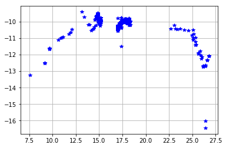

```python
import matplotlib
%matplotlib inline
from matplotlib import pyplot as plt

import numpy as np
x = np.log10(df_sed['freq'])
y = np.log10(df_sed['flux'])
#y = df_sed['flux']

plt.plot(x, y, 'b*')
plt.grid(True)
```